# Josh Barlow

## Sports Analytics

[figure not shown]

```python
from IPython.display import Image
from IPython.core.display import HTML
Image("images/2016-nfl-predictions.png")
```

The University of Toronto Sports Analytics Group defines sports analytics as "the process of using sports-related data (anything from player statistics to game day weather) to find meaningful patterns (strong correlations, hidden trends, etc.) and communicate those patterns (using graphs, charts, essays, etc.) to help make decisions". They go on to explain that there are four elements to the sports analytics framework and they are data management, analytic models, information systems, and the decision maker.

```python
Image(url= "http://sportsanalytics.sa.utoronto.ca/files/2014/12/Fig1.png")
```

[figure not shown]

These are fairly self explanatory. Analysts need to compile the initial data in the data management stage, build or adjust the appropriate models to analyze the data, extract the pertinent information and provide the information to the decision makers, and make an informed decisions. There are many ways that this information can be used. It can be used by coaches to make decisions on where to focus their efforts in weekly practice or they can use it to help decide what key positions to focus on during the draft or player signings. Owners and team managers can use analytics to look at prospective coaches as seen in the image below. On the other end of the spectrum, it can be used by fantasy leagues for predictions or for setting odds in gambling (not that I condone that behavior). There really is no limit to the what analytics can be used for to gain a competitive advantage.

[figure not shown]

```python
Image("images/coaches.png")
```

The models provided below show that based on season statistics in the National Football League, fairly accurate predictions can be made on who will win the Super Bowl. Obviously, there are a lot of outside factors that can affect a team in the playoffs that are impossible to predict such as injuries to key players. As is the case in all sports, there is never a sure thing but based on season statistics from 1970 to 2015 I have put together some models in an attempt to predict the future.

## Step 1: Data Management

I imported data from 1970 to 2015 from https://www.pro-football-reference.com/years/. Once this data was imported, the offense and defense tables had to be merged by team by year. Based on overall performance for the season through the championship game, each team was given an overall ranking for that year with number 1 being the Super Bowl champion, number 2 the loser of the Super Bowl, etc. The overall ranking was based on where the team finished in the playoffs. The teams that did not make it to the post season were ranked based on their overall record for the season. Teams that shared the same win/loss records were given the same ranking for the season (i.e. if three teams finished at 8-8 and they would have been ranked 15, 16, and 17, then all three were ranked 15 and the next team was ranked 18 and so on). This was done for each year and the overall ranking for each year is what will be used for the y-variable in the regression models.

To run the data through regression models, first the appropriate packages need to be imported.

```python
import pandas as pd
import numpy as np
import seaborn as sns
import matplotlib.pyplot as plt
%matplotlib inline

#regression packages
import sklearn.linear_model as lm
from sklearn.metrics import mean_squared_error
from sklearn.metrics import explained_variance_score
import statsmodels.formula.api as sm

#lasso regression
from sklearn import linear_model

#elasticnet regression
from sklearn.linear_model import ElasticNet
from sklearn.datasets import make_regression

#f_regression (feature selection)
from sklearn.feature_selection import f_regression
from sklearn.feature_selection import SelectKBest

# recursive feature selection (feature selection)
from sklearn.feature_selection import RFE
```

Next the raw data to be used in building the regression models is imported and saved under data. Below is the first five rows of that table.

```python
data = pd.read_csv("data/NFLData.csv")
data.head()
```

|  | Overall | Off_Rank | Team | Games | Points | Yards | Off_Plays | Fum_Lost | Fdowns | Pass_Comp | ... | Pass_TD_Allowed | Interceptions | Def_Pass_NYPA | Pass_1stD_Allowed | Rush_Yds_Allowed | Rush_TD_Allowed | Def_Rush_YPA | Rush_1stD_Allowed | Def_Pen | Def_Pen_Yds |
| --- | --- | --- | --- | --- | --- | --- | --- | --- | --- | --- | --- | --- | --- | --- | --- | --- | --- | --- | --- | --- | --- |
| 0 | 3 | 1 | San Francisco 49ers | 14 | 352 | 4503 | 862 | 15 | 237 | 226 | ... | 19 | 22 | 5.2 | 110 | 1799 | 12 | 4.2 | 81 | 87 | 965 |
| 1 | 5 | 3 | Minnesota Vikings | 14 | 335 | 3815 | 881 | 16 | 225 | 173 | ... | 6 | 28 | 3.5 | 89 | 1365 | 4 | 3.4 | 68 | 58 | 586 |
| 2 | 6 | 2 | Detroit Lions | 14 | 347 | 3984 | 844 | 15 | 243 | 167 | ... | 14 | 28 | 5.8 | 112 | 1152 | 7 | 3.2 | 61 | 90 | 805 |
| 3 | 9 | 5 | Los Angeles Rams | 14 | 325 | 4271 | 879 | 17 | 224 | 218 | ... | 15 | 19 | 5.1 | 113 | 1359 | 6 | 3.4 | 64 | 77 | 825 |
| 4 | 11 | 4 | St. Louis Cardinals | 14 | 325 | 4471 | 845 | 14 | 226 | 178 | ... | 16 | 21 | 5.0 | 116 | 1762 | 10 | 3.7 | 96 | 68 | 659 |

5 rows × 40 columns

Below is an explanation of what each column stands for (these are the columns that can be used in regression analysis):

- Note: Data used was regular season data between 1970-2015. All variables are statistics for the entire regular season. The models are designed to be able to enter the regular season data and predict the team rankings for that season through the post-season.

Overall: Team rank at end of season  
Off_Rank: Team Offensive rank  
Team: Team name  
Games: Number of games played  
Points: Total points scored  
Yards: Total yards accumulated  
Off_Plays: Total offensive plays executed  
Fum_Lost: Total offensive fumbles lost  
Fdowns: Total first downs  
Pass_Comp: Total completed passes  
Pass_Att: Total attempted passes  
Pass_Yds: Total passing yards  
Pass_TD: Total passing touchdowns  
Pass_Int: Total interceptions thrown  
Pass_NYPA: Net yards per passing attempt  
Pass_1stD: Total passing firstdowns  
Rush_Att: Total rushing attempts  
Rush_Yds: Total rushing yards  
Rush_TD: Total rushing touchdowns  
Rush_YPA: Average rushing yards per attemps  
Rush_1stD: Total rushing firstdowns  
Off_Pen: Total offensive penalties  
Off_Pen_Yds: Total offensive penalty yards  
Def_Rank: Team Defensive rank  
Opp_Points: Total opponent points allowed  
Yds_Allowed: Total opponent yards allowed  
Def_YPP: Opponent average yards per play  
Takeaways: Total takeaways  
Fdowns_Allowed: Opponent firstdowns allowed  
Pass_Yds_Allowed: Opponent passing yards allowed  
Pass_TD_Allowed: Opponent passing touchdowns allowed  
Interceptions: Total interceptions  
Def_Pass_NYPA: Opponent net yards per passing attempt allowed  
Pass_1stD_Allowed: Opponent passing firstdowns allowed  
Rush_Yds_Allowed: Opponent rushing yards allowed  
Rush_TD_Allowed: Opponent rushing touchdowns allowed  
Def_Rush_YPA: Opponent average rushing yards per attempt allowed  
Rush_1stD_Allowed: Opponent rushing firstdowns allowed  
Def_Pen: Total defensive penalties  
Def_Pen_Yds: Total defensive penalty yards

Now that the data is imported, a correlation heat map can be displayed to show all available variables with their correlation to eachother and to what will be the y-variable (overall). As you can see, the far left column shows each variable's correlation to "Overall". Throughout the chart you can also see that some of the variables have a strong positive or negative correlation to eachother. With this being the case, care needs to be taken in what X-variables are used to avoid too much multicollinearity.

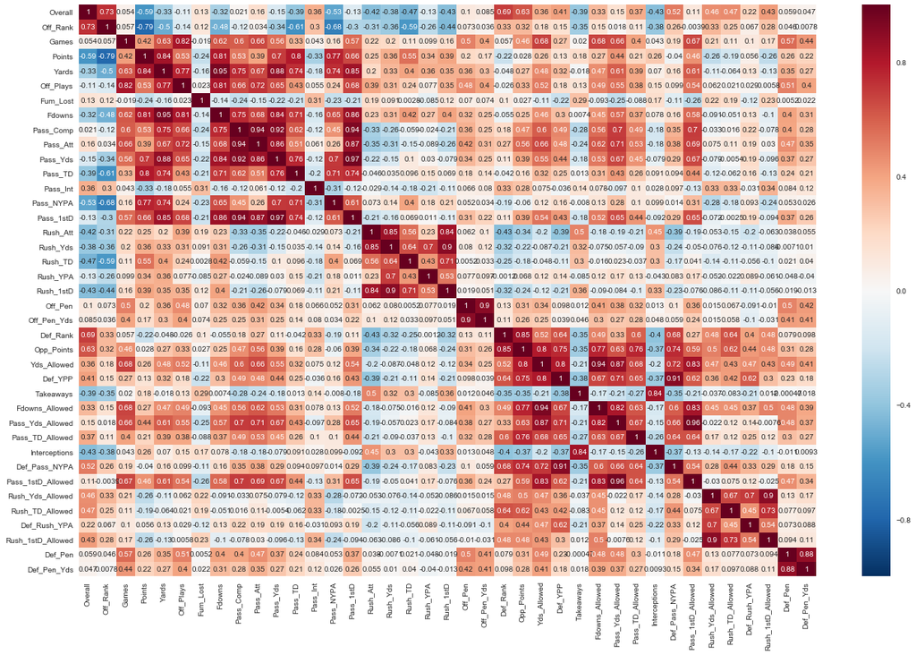

```python
# correlation heatmap provides visual representation of the relationships of all variables
plt.figure(figsize=(22,14))
sns.heatmap(data.corr(), annot=True)
```

## 2. Analytic Models

Next the variables are put into different linear regression models. There are multiple models that can be used including ordinary least squares, lasso, ridge, and elasticnet.

### Least Squares Model using all available X-variables

The data is put into the Least Squares Model and the output below shows the coefficient for each X-variable along with the y-intercept.

```python
# data is updated to eliminate "Team" and "Games" from the X-variables as these variables do not affect the outcome
data = data.drop(['Team', 'Games'], axis=1)
```

```python
# assigning columns to X and Y variables; currently all x-variables available are being used
y = data['Overall']
X = data.drop(['Overall'], axis =1)
```

```python
# fit the data to an ordinary least squares regression model
linearmodel1 = lm.LinearRegression()
linearmodel1.fit(X, y)
linearmodel1_y = linearmodel1.predict(X)
```

```python
# print the coefficients for each X-variable and the Y-intercept
print 'Coefficients: ', linearmodel1.coef_
print "y-intercept ", linearmodel1.intercept_
```

```
Coefficients:  [  3.34826682e-01  -2.29921061e-02  -1.69812726e+11   5.69245904e-02
  -5.55836295e-02  -2.38071500e-02   2.17695089e-02  -4.04616652e-02
   1.69812726e+11   4.06475067e-02   6.70909882e-02   6.28747106e-01
  -3.62396240e-02  -6.38885498e-02   1.69812726e+11   1.44812584e-01
   1.22385836e+00   2.56233215e-02  -8.89015198e-03   2.07519531e-03
   1.66564941e-01   3.01036835e-02   2.92157109e+11   3.10669932e+00
  -3.79943848e-03  -3.70693207e-02  -2.92157109e+11   6.41870499e-02
   3.88050079e-02   8.47666264e-01   8.47949982e-02  -2.92157109e+11
   5.83024025e-02  -3.53826460e+00  -1.45015717e-02   2.19602585e-02
  -1.95312500e-03]
y-intercept  -8.99084104665
```

We can also display the coefficients in a table to make them easier to read and compare.

```python
coef = ["%.3f" % i for i in linearmodel1.coef_]
xcolumns = [ i for i in X.columns ]
pd.DataFrame(zip(xcolumns, coef))
```

|  | 0 | 1 |
| --- | --- | --- |
| 0 | Off_Rank | 0.335 |
| 1 | Points | -0.023 |
| 2 | Yards | -169812725936.159 |
| 3 | Off_Plays | 0.057 |
| 4 | Fum_Lost | -0.056 |
| 5 | Fdowns | -0.024 |
| 6 | Pass_Comp | 0.022 |
| 7 | Pass_Att | -0.040 |
| 8 | Pass_Yds | 169812725936.159 |
| 9 | Pass_TD | 0.041 |
| 10 | Pass_Int | 0.067 |
| 11 | Pass_NYPA | 0.629 |
| 12 | Pass_1stD | -0.036 |
| 13 | Rush_Att | -0.064 |
| 14 | Rush_Yds | 169812725936.158 |
| 15 | Rush_TD | 0.145 |
| 16 | Rush_YPA | 1.224 |
| 17 | Rush_1stD | 0.026 |
| 18 | Off_Pen | -0.009 |
| 19 | Off_Pen_Yds | 0.002 |
| 20 | Def_Rank | 0.167 |
| 21 | Opp_Points | 0.030 |
| 22 | Yds_Allowed | 292157108686.636 |
| 23 | Def_YPP | 3.107 |
| 24 | Takeaways | -0.004 |
| 25 | Fdowns_Allowed | -0.037 |
| 26 | Pass_Yds_Allowed | -292157108686.641 |
| 27 | Pass_TD_Allowed | 0.064 |
| 28 | Interceptions | 0.039 |
| 29 | Def_Pass_NYPA | 0.848 |
| 30 | Pass_1stD_Allowed | 0.085 |
| 31 | Rush_Yds_Allowed | -292157108686.632 |
| 32 | Rush_TD_Allowed | 0.058 |
| 33 | Def_Rush_YPA | -3.538 |
| 34 | Rush_1stD_Allowed | -0.015 |
| 35 | Def_Pen | 0.022 |
| 36 | Def_Pen_Yds | -0.002 |

The coefficients for the first model are displayed in the table above. According to Analytics Vidhya, "a large coefficient signifies that a lot of emphasis is being put on that feature, i.e. the particular feature is a good predictor for the outcome. When it becomes too large, the algorithm starts modelling intricate relations to estimate the output and ends up overfitting to the particular training data".

```python
# print mean square error and r-squared
print "mean square error: ", mean_squared_error(y, linearmodel1_y)
print "variance or r-squared: ", explained_variance_score(y, linearmodel1_y)
```

```
mean square error:  15.0789045687
variance or r-squared:  0.781904436066
```

Now we can load the 2016 regular season data (without the overall team rankings) and run it through the Least Squares Model. The first five predictions are displayed below (note that they are not in order yet).

```python
# load the 2016 regular season data
rank = pd.read_csv("data/2016.csv")
rank = pd.DataFrame(rank)
rank.head()
```

|  | Off_Rank | Team | Games | Points | Yards | Off_Plays | Fum_Lost | Fdowns | Pass_Comp | Pass_Att | ... | Pass_TD_Allowed | Interceptions | Def_Pass_NYPA | Pass_1stD_Allowed | Rush_Yds_Allowed | Rush_TD_Allowed | Def_Rush_YPA | Rush_1stD_Allowed | Def_Pen | Def_Pen_Yds |
| --- | --- | --- | --- | --- | --- | --- | --- | --- | --- | --- | --- | --- | --- | --- | --- | --- | --- | --- | --- | --- | --- |
| 0 | 1 | Atlanta Falcons | 16 | 540 | 6653 | 995 | 4 | 379 | 374 | 537 | ... | 31 | 12 | 6.2 | 232 | 1672 | 15 | 4.5 | 95 | 113 | 974 |
| 1 | 3 | New England Patriots | 16 | 441 | 6180 | 1056 | 9 | 351 | 368 | 550 | ... | 21 | 13 | 6.0 | 190 | 1417 | 6 | 3.9 | 81 | 113 | 930 |
| 2 | 2 | New Orleans Saints | 16 | 469 | 6816 | 1105 | 9 | 395 | 472 | 674 | ... | 27 | 9 | 7.2 | 230 | 1626 | 19 | 4.1 | 91 | 104 | 881 |
| 3 | 26 | New York Giants | 16 | 310 | 5291 | 1018 | 11 | 289 | 377 | 598 | ... | 15 | 17 | 6.0 | 191 | 1417 | 10 | 3.6 | 82 | 104 | 853 |
| 4 | 18 | Seattle Seahawks | 16 | 354 | 5715 | 1012 | 6 | 313 | 368 | 567 | ... | 16 | 11 | 6.2 | 180 | 1487 | 16 | 3.4 | 94 | 103 | 925 |

5 rows × 39 columns

```python
# Use linearmodel1 to predict y value; we are still using all available X-variables for this test
columns = rank[['Off_Rank', 'Points', 'Yards', 'Off_Plays', 'Fum_Lost', 'Fdowns', 'Pass_Comp', 'Pass_Att',
                'Pass_Yds', 'Pass_TD', 'Pass_Int', 'Pass_NYPA', 'Pass_1stD', 'Rush_Att', 'Rush_Yds', 'Rush_TD',
                'Rush_YPA', 'Rush_1stD', 'Off_Pen', 'Off_Pen_Yds', 'Def_Rank', 'Opp_Points', 'Yds_Allowed',
                'Def_YPP', 'Takeaways', 'Fdowns_Allowed', 'Pass_Yds_Allowed', 'Pass_TD_Allowed', 'Interceptions',
                'Def_Pass_NYPA', 'Pass_1stD_Allowed', 'Rush_Yds_Allowed', 'Rush_TD_Allowed', 'Def_Rush_YPA',
                'Rush_1stD_Allowed', 'Def_Pen', 'Def_Pen_Yds']]
```

```python
# put the columns from above into a dataframe named "predict"
predict = pd.DataFrame(linearmodel1.predict(columns))
predict.head()
```

|  | 0 |
| --- | --- |
| 0 | 7.288020 |
| 1 | 0.237717 |
| 2 | 15.166040 |
| 3 | 12.845653 |
| 4 | 11.566516 |

```python
# rename the predict column
predict = predict.rename(columns={0: 'Predicted Overall'})
predict.head()
```

|  | Predicted Overall |
| --- | --- |
| 0 | 7.288020 |
| 1 | 0.237717 |
| 2 | 15.166040 |
| 3 | 12.845653 |
| 4 | 11.566516 |

```python
# put the Team and Predicted Overall ranking in a table together and ensure the columns are labeled correctly
predict = pd.DataFrame(zip(rank['Team'], predict['Predicted Overall']))
predict.head()
```

|  | 0 | 1 |
| --- | --- | --- |
| 0 | Atlanta Falcons | 7.288020 |
| 1 | New England Patriots | 0.237717 |
| 2 | New Orleans Saints | 15.166040 |
| 3 | New York Giants | 12.845653 |
| 4 | Seattle Seahawks | 11.566516 |

```python
# rename the columns
predict = predict.rename(columns={0: 'Team', 1: 'Predicted Overall'})
predict.head()
```

|  | Team | Predicted Overall |
| --- | --- | --- |
| 0 | Atlanta Falcons | 7.288020 |
| 1 | New England Patriots | 0.237717 |
| 2 | New Orleans Saints | 15.166040 |
| 3 | New York Giants | 12.845653 |
| 4 | Seattle Seahawks | 11.566516 |

Now the actual team rankings for the 2016 season are loaded so they can be compared to the predicted values. Notice that the "Predicted Overall" output is not whole numbers 1 to 32 (32 being the number of teams in the league). However, the teams are ranked against eachother based on the predicted overall result. This can then be sorted and given a reference column that does list 1 to 32.  
Just above the table output below you can see that the model correctly predicted 7 overall rankings and it also correctly predicted the Super Bowl winner.

```python
# load the 2016 season overall rangings and put it into a dataframe
actual = pd.read_csv("data/2016Actual.csv")
actual.head()
```

|  | Actual Finish | Team |
| --- | --- | --- |
| 0 | 2 | Atlanta Falcons |
| 1 | 1 | New England Patriots |
| 2 | 21 | New Orleans Saints |
| 3 | 10 | New York Giants |
| 4 | 7 | Seattle Seahawks |

```python
# Sort the predict chart by "Predicted overall". This ranks the teams by predicted regular season finish.
predict = predict.sort_values(by=["Predicted Overall"], ascending=[True])
predict.head()
```

|  | Team | Predicted Overall |
| --- | --- | --- |
| 1 | New England Patriots | 0.237717 |
| 7 | Dallas Cowboys | 4.846698 |
| 0 | Atlanta Falcons | 7.288020 |
| 16 | Pittsburgh Steelers | 8.513301 |
| 11 | Kansas City Chiefs | 9.631686 |

```python
# Create a new column named "Predicted Rank". This creates a column listing 1 to 32 due to the predicted rankings
# lack of whole number structure
predict = predict.reset_index()
predict['Predicted Rank'] = predict.index+1
predict.head()
```

|  | index | Team | Predicted Overall | Predicted Rank |
| --- | --- | --- | --- | --- |
| 0 | 1 | New England Patriots | 0.237717 | 1 |
| 1 | 7 | Dallas Cowboys | 4.846698 | 2 |
| 2 | 0 | Atlanta Falcons | 7.288020 | 3 |
| 3 | 16 | Pittsburgh Steelers | 8.513301 | 4 |
| 4 | 11 | Kansas City Chiefs | 9.631686 | 5 |

```python
# Delete the index column that the above code creates
del predict['index']
predict.head()
```

|  | Team | Predicted Overall | Predicted Rank |
| --- | --- | --- | --- |
| 0 | New England Patriots | 0.237717 | 1 |
| 1 | Dallas Cowboys | 4.846698 | 2 |
| 2 | Atlanta Falcons | 7.288020 | 3 |
| 3 | Pittsburgh Steelers | 8.513301 | 4 |
| 4 | Kansas City Chiefs | 9.631686 | 5 |

```python
# merge the predict and actual data into one table
predict = pd.merge(predict, actual, on='Team')
predict.head()
```

|  | Team | Predicted Overall | Predicted Rank | Actual Finish |
| --- | --- | --- | --- | --- |
| 0 | New England Patriots | 0.237717 | 1 | 1 |
| 1 | Dallas Cowboys | 4.846698 | 2 | 5 |
| 2 | Atlanta Falcons | 7.288020 | 3 | 2 |
| 3 | Pittsburgh Steelers | 8.513301 | 4 | 3 |
| 4 | Kansas City Chiefs | 9.631686 | 5 | 6 |

```python
# create a new column that contains the difference between predicted and actual overall rankings
predict['Difference']= (predict['Predicted Rank'] - predict['Actual Finish'])
predict.head()
```

|  | Team | Predicted Overall | Predicted Rank | Actual Finish | Difference |
| --- | --- | --- | --- | --- | --- |
| 0 | New England Patriots | 0.237717 | 1 | 1 | 0 |
| 1 | Dallas Cowboys | 4.846698 | 2 | 5 | -3 |
| 2 | Atlanta Falcons | 7.288020 | 3 | 2 | 1 |
| 3 | Pittsburgh Steelers | 8.513301 | 4 | 3 | 1 |
| 4 | Kansas City Chiefs | 9.631686 | 5 | 6 | -1 |

```python
# create a new column that contains the percent difference
predict['% Difference']= (((predict['Predicted Rank'] - predict['Actual Finish']) / predict['Predicted Rank']) * 100)
predict.head()
```

|  | Team | Predicted Overall | Predicted Rank | Actual Finish | Difference | % Difference |
| --- | --- | --- | --- | --- | --- | --- |
| 0 | New England Patriots | 0.237717 | 1 | 1 | 0 | 0.000000 |
| 1 | Dallas Cowboys | 4.846698 | 2 | 5 | -3 | -150.000000 |
| 2 | Atlanta Falcons | 7.288020 | 3 | 2 | 1 | 33.333333 |
| 3 | Pittsburgh Steelers | 8.513301 | 4 | 3 | 1 | 25.000000 |
| 4 | Kansas City Chiefs | 9.631686 | 5 | 6 | -1 | -20.000000 |

```python
# clean up the % Difference column so it is more appealing and readable, eliminating the decimals
predict['% Difference'] = predict['% Difference'].astype(int).abs()
predict.head()
```

|  | Team | Predicted Overall | Predicted Rank | Actual Finish | Difference | % Difference |
| --- | --- | --- | --- | --- | --- | --- |
| 0 | New England Patriots | 0.237717 | 1 | 1 | 0 | 0 |
| 1 | Dallas Cowboys | 4.846698 | 2 | 5 | -3 | 150 |
| 2 | Atlanta Falcons | 7.288020 | 3 | 2 | 1 | 33 |
| 3 | Pittsburgh Steelers | 8.513301 | 4 | 3 | 1 | 25 |
| 4 | Kansas City Chiefs | 9.631686 | 5 | 6 | -1 | 20 |

```python
Image(url= "https://wikimedia.org/api/rest_v1/media/math/render/svg/67b9ac7353c6a2710e35180238efe54faf4d9c15")
```

[figure not shown]

```python
# calculate Mean Square Error (MSE) of the predictions
# i is already the difference between Y in the MSE formula above so we simply square it. Then the sum of the squares is divided
# by the number of predictions (which is count)
mse = 0
count = 0
for i in predict['Difference']:
    count += 1
    mse += (i*i)
linearmodel1_mse = float(mse) / float(count)
print '%s %s' %("linearmodel1 Mean Square Error: ", "%.3f" % linearmodel1_mse)
```

```
linearmodel1 Mean Square Error:  40.719
```

```python
# Now we can loop through the 'Difference' column. Count will give us the total number of zeros in the difference column;
# these are correct predictions
count1 = 0
for i in predict['Difference']:
    if i == 0:
        count1+=1
print '%s %s' %("Number of rankings correctly predicted: ", count1)
```

```
Number of rankings correctly predicted:  7
```

```python
# Check the first row of the difference column. If this value is a zero, the model correctly predicted the Super Bowl winner
a = 0
for i in predict['Difference']:
    a+=1
    if a == 1:
        if i == 0:
            print("THE MODEL CORRECTLY PREDICTED THE SUPER BOWL WINNER!!!")
        else:
            print("The model did not predict the Super Bowl winner.")
```

```
THE MODEL CORRECTLY PREDICTED THE SUPER BOWL WINNER!!!
```

```python
# Now display everything together with the table
a = 0
for i in predict['Difference']:
    a+=1
    if a == 1:
        if i == 0:
            print("THE MODEL CORRECTLY PREDICTED THE SUPER BOWL WINNER!!!")
        else:
            print("The model did not predict the Super Bowl winner.")

print '%s %s' %("Number of rankings correctly predicted: ", count1)
print '%s %s' %("linearmodel1 Mean Square Error: ", "%.3f" % linearmodel1_mse)
predict
```

```
THE MODEL CORRECTLY PREDICTED THE SUPER BOWL WINNER!!!
Number of rankings correctly predicted:  7
linearmodel1 Mean Square Error:  40.719
```

|  | Team | Predicted Overall | Predicted Rank | Actual Finish | Difference | % Difference |
| --- | --- | --- | --- | --- | --- | --- |
| 0 | New England Patriots | 0.237717 | 1 | 1 | 0 | 0 |
| 1 | Dallas Cowboys | 4.846698 | 2 | 5 | -3 | 150 |
| 2 | Atlanta Falcons | 7.288020 | 3 | 2 | 1 | 33 |
| 3 | Pittsburgh Steelers | 8.513301 | 4 | 3 | 1 | 25 |
| 4 | Kansas City Chiefs | 9.631686 | 5 | 6 | -1 | 20 |
| 5 | Arizona Cardinals | 11.377559 | 6 | 20 | -14 | 233 |
| 6 | Seattle Seahawks | 11.566516 | 7 | 7 | 0 | 0 |
| 7 | Denver Broncos | 12.811533 | 8 | 13 | -5 | 62 |
| 8 | New York Giants | 12.845653 | 9 | 10 | -1 | 11 |
| 9 | Indianapolis Colts | 12.906971 | 10 | 17 | -7 | 70 |
| 10 | Oakland Raiders | 13.224475 | 11 | 9 | 2 | 18 |
| 11 | Tennessee Titans | 13.356398 | 12 | 13 | -1 | 8 |
| 12 | Cincinnati Bengals | 13.463133 | 13 | 24 | -11 | 84 |
| 13 | Green Bay Packers | 13.535657 | 14 | 4 | 10 | 71 |
| 14 | Philadelphia Eagles | 13.542632 | 15 | 21 | -6 | 40 |
| 15 | Washington Redskins | 13.874522 | 16 | 16 | 0 | 0 |
| 16 | Minnesota Vikings | 13.911770 | 17 | 17 | 0 | 0 |
| 17 | Tampa Bay Buccaneers | 14.608596 | 18 | 13 | 5 | 27 |
| 18 | San Diego Chargers | 14.912153 | 19 | 26 | -7 | 36 |
| 19 | New Orleans Saints | 15.166040 | 20 | 21 | -1 | 5 |
| 20 | Buffalo Bills | 15.518352 | 21 | 21 | 0 | 0 |
| 21 | Detroit Lions | 15.676100 | 22 | 12 | 10 | 45 |
| 22 | Carolina Panthers | 16.609177 | 23 | 25 | -2 | 8 |
| 23 | Miami Dolphins | 16.743193 | 24 | 11 | 13 | 54 |
| 24 | Baltimore Ravens | 17.983939 | 25 | 17 | 8 | 32 |
| 25 | Houston Texans | 19.064849 | 26 | 8 | 18 | 69 |
| 26 | Jacksonville Jaguars | 21.135172 | 27 | 29 | -2 | 7 |
| 27 | Chicago Bears | 22.568442 | 28 | 29 | -1 | 3 |
| 28 | Los Angeles Rams | 27.102246 | 29 | 28 | 1 | 3 |
| 29 | New York Jets | 27.665346 | 30 | 26 | 4 | 13 |
| 30 | San Francisco 49ers | 27.817399 | 31 | 31 | 0 | 0 |
| 31 | Cleveland Browns | 32.495355 | 32 | 32 | 0 | 0 |

### Lasso Model using all available X-variables

Next the same thing is done but using a Lasso (least absolute shrinkage and selection operator) model. The Lasso Model performs both variable selection and regularization in order to enhance the prediction accuracy and interpretability of the statistical model it produces. This helps reduce error due to some highly correlated X-variables.

```python
#Fit the model using the same X and Y variables as previous model
lassomodel1 = linear_model.Lasso(alpha=1)
lassomodel1.fit(X, y)
lassomodel1_y = lassomodel1.predict(X)

coef = ["%.3f" % i for i in lassomodel1.coef_]
xcolumns = [ i for i in X.columns ]
pd.DataFrame(zip(xcolumns, coef))
```

|  | 0 | 1 |
| --- | --- | --- |
| 0 | Off_Rank | 0.181 |
| 1 | Points | -0.042 |
| 2 | Yards | 0.000 |
| 3 | Off_Plays | 0.004 |
| 4 | Fum_Lost | -0.000 |
| 5 | Fdowns | 0.000 |
| 6 | Pass_Comp | 0.003 |
| 7 | Pass_Att | 0.005 |
| 8 | Pass_Yds | -0.001 |
| 9 | Pass_TD | -0.000 |
| 10 | Pass_Int | 0.000 |
| 11 | Pass_NYPA | -0.000 |
| 12 | Pass_1stD | 0.000 |
| 13 | Rush_Att | -0.022 |
| 14 | Rush_Yds | 0.002 |
| 15 | Rush_TD | 0.000 |
| 16 | Rush_YPA | 0.000 |
| 17 | Rush_1stD | 0.000 |
| 18 | Off_Pen | -0.000 |
| 19 | Off_Pen_Yds | 0.001 |
| 20 | Def_Rank | 0.070 |
| 21 | Opp_Points | 0.060 |
| 22 | Yds_Allowed | 0.000 |
| 23 | Def_YPP | 0.000 |
| 24 | Takeaways | -0.000 |
| 25 | Fdowns_Allowed | -0.009 |
| 26 | Pass_Yds_Allowed | -0.000 |
| 27 | Pass_TD_Allowed | 0.000 |
| 28 | Interceptions | -0.000 |
| 29 | Def_Pass_NYPA | 0.000 |
| 30 | Pass_1stD_Allowed | -0.000 |
| 31 | Rush_Yds_Allowed | 0.001 |
| 32 | Rush_TD_Allowed | -0.000 |
| 33 | Def_Rush_YPA | -0.000 |
| 34 | Rush_1stD_Allowed | -0.000 |
| 35 | Def_Pen | 0.000 |
| 36 | Def_Pen_Yds | -0.000 |

Note that now there are a lot more zero coefficients, this is how the lasso model deals with multicolinearity.

```python
print "mean square error: ", mean_squared_error(y, lassomodel1_y)
print "variance or r-squared: ", explained_variance_score(y, lassomodel1_y)
```

```
mean square error:  15.139805591
variance or r-squared:  0.780648038237
```

```python
# Use lassomodel1 to predict y value; we are still using all x-variables for this model
columns = rank[['Off_Rank', 'Points', 'Yards', 'Off_Plays', 'Fum_Lost', 'Fdowns', 'Pass_Comp',
                  'Pass_Att', 'Pass_Yds', 'Pass_TD', 'Pass_Int', 'Pass_NYPA', 'Pass_1stD', 'Rush_Att',
                  'Rush_Yds', 'Rush_TD', 'Rush_YPA', 'Rush_1stD', 'Off_Pen', 'Off_Pen_Yds', 'Def_Rank',
                  'Opp_Points', 'Yds_Allowed', 'Def_YPP', 'Takeaways', 'Fdowns_Allowed', 'Pass_Yds_Allowed',
                  'Pass_TD_Allowed', 'Interceptions', 'Def_Pass_NYPA', 'Pass_1stD_Allowed', 'Rush_Yds_Allowed',
                  'Rush_TD_Allowed', 'Def_Rush_YPA', 'Rush_1stD_Allowed', 'Def_Pen', 'Def_Pen_Yds']]
```

```python
# like before, we are now putting the desired columns into a predict table
predict2 = pd.DataFrame(lassomodel1.predict(columns))
predict2 = predict2.rename(columns={0: 'Predicted Overall'})
predict2.head()
```

|  | Predicted Overall |
| --- | --- |
| 0 | 7.074539 |
| 1 | 0.310445 |
| 2 | 14.548719 |
| 3 | 13.660039 |
| 4 | 10.824481 |

```python
# put Team name and predicted overall rank in a table together
predict2 = pd.DataFrame(zip(rank['Team'], predict2['Predicted Overall']))
predict2.head()
```

|  | 0 | 1 |
| --- | --- | --- |
| 0 | Atlanta Falcons | 7.074539 |
| 1 | New England Patriots | 0.310445 |
| 2 | New Orleans Saints | 14.548719 |
| 3 | New York Giants | 13.660039 |
| 4 | Seattle Seahawks | 10.824481 |

```python
# rename the columns
predict2 = predict2.rename(columns={0: 'Team', 1: 'Predicted Overall'})
predict2.head()
```

|  | Team | Predicted Overall |
| --- | --- | --- |
| 0 | Atlanta Falcons | 7.074539 |
| 1 | New England Patriots | 0.310445 |
| 2 | New Orleans Saints | 14.548719 |
| 3 | New York Giants | 13.660039 |
| 4 | Seattle Seahawks | 10.824481 |

Same process as the previous model

```python
# sort the table from first to last predicted rank
predict2 = predict2.sort_values(by=["Predicted Overall"], ascending=[True])
predict2.head()
```

|  | Team | Predicted Overall |
| --- | --- | --- |
| 1 | New England Patriots | 0.310445 |
| 7 | Dallas Cowboys | 5.810985 |
| 0 | Atlanta Falcons | 7.074539 |
| 11 | Kansas City Chiefs | 10.027173 |
| 16 | Pittsburgh Steelers | 10.484183 |

```python
# create a reference column that will list 1 to 32 for rankings
predict2 = predict2.reset_index()
predict2['Predicted Rank'] = predict2.index+1
predict2.head()
```

|  | index | Team | Predicted Overall | Predicted Rank |
| --- | --- | --- | --- | --- |
| 0 | 1 | New England Patriots | 0.310445 | 1 |
| 1 | 7 | Dallas Cowboys | 5.810985 | 2 |
| 2 | 0 | Atlanta Falcons | 7.074539 | 3 |
| 3 | 11 | Kansas City Chiefs | 10.027173 | 4 |
| 4 | 16 | Pittsburgh Steelers | 10.484183 | 5 |

```python
# remove the index column
del predict2['index']
predict2.head()
```

|  | Team | Predicted Overall | Predicted Rank |
| --- | --- | --- | --- |
| 0 | New England Patriots | 0.310445 | 1 |
| 1 | Dallas Cowboys | 5.810985 | 2 |
| 2 | Atlanta Falcons | 7.074539 | 3 |
| 3 | Kansas City Chiefs | 10.027173 | 4 |
| 4 | Pittsburgh Steelers | 10.484183 | 5 |

```python
# merge the predict2 table with the actual ranks
predict2 = pd.merge(predict2, actual, on='Team')
predict2.head()
```

|  | Team | Predicted Overall | Predicted Rank | Actual Finish |
| --- | --- | --- | --- | --- |
| 0 | New England Patriots | 0.310445 | 1 | 1 |
| 1 | Dallas Cowboys | 5.810985 | 2 | 5 |
| 2 | Atlanta Falcons | 7.074539 | 3 | 2 |
| 3 | Kansas City Chiefs | 10.027173 | 4 | 6 |
| 4 | Pittsburgh Steelers | 10.484183 | 5 | 3 |

```python
# create a new column that contains the difference between predicted and actual overall rankings
predict2['Difference']= (predict2['Predicted Rank'] - predict2['Actual Finish'])
predict2.head()
```

|  | Team | Predicted Overall | Predicted Rank | Actual Finish | Difference |
| --- | --- | --- | --- | --- | --- |
| 0 | New England Patriots | 0.310445 | 1 | 1 | 0 |
| 1 | Dallas Cowboys | 5.810985 | 2 | 5 | -3 |
| 2 | Atlanta Falcons | 7.074539 | 3 | 2 | 1 |
| 3 | Kansas City Chiefs | 10.027173 | 4 | 6 | -2 |
| 4 | Pittsburgh Steelers | 10.484183 | 5 | 3 | 2 |

```python
# create a column that shows the percent difference for predicted and actual rank
predict2['% Difference']= (((predict2['Predicted Rank'] - predict2['Actual Finish']) / predict2['Predicted Rank']) * 100)
predict2.head()
```

|  | Team | Predicted Overall | Predicted Rank | Actual Finish | Difference | % Difference |
| --- | --- | --- | --- | --- | --- | --- |
| 0 | New England Patriots | 0.310445 | 1 | 1 | 0 | 0.000000 |
| 1 | Dallas Cowboys | 5.810985 | 2 | 5 | -3 | -150.000000 |
| 2 | Atlanta Falcons | 7.074539 | 3 | 2 | 1 | 33.333333 |
| 3 | Kansas City Chiefs | 10.027173 | 4 | 6 | -2 | -50.000000 |
| 4 | Pittsburgh Steelers | 10.484183 | 5 | 3 | 2 | 40.000000 |

```python
# clean up the % Change column so it is more appealing and readable, eliminating the decimals
predict2['% Difference'] = predict2['% Difference'].astype(int).abs()
predict2.head()
```

|  | Team | Predicted Overall | Predicted Rank | Actual Finish | Difference | % Difference |
| --- | --- | --- | --- | --- | --- | --- |
| 0 | New England Patriots | 0.310445 | 1 | 1 | 0 | 0 |
| 1 | Dallas Cowboys | 5.810985 | 2 | 5 | -3 | 150 |
| 2 | Atlanta Falcons | 7.074539 | 3 | 2 | 1 | 33 |
| 3 | Kansas City Chiefs | 10.027173 | 4 | 6 | -2 | 50 |
| 4 | Pittsburgh Steelers | 10.484183 | 5 | 3 | 2 | 40 |

```python
# calculate Mean Square Error (MSE) of the predictions
# i is already the difference between Y in the MSE formula so we simply square it. Then the sum of the squares is divided
# by the number of predictions (which is count)
mse = 0
count = 0
for i in predict2['Difference']:
    count += 1
    mse += (i*i)
lassomodel1_mse = float(mse) / float(count)
print '%s %s' %("lassomodel1 Mean Square Error: ", "%.3f" % lassomodel1_mse)
```

```
lassomodel1 Mean Square Error:  37.094
```

```python
# count will give us the total number of zeros in the difference column; these are correct predictions
# note "count2" is used; this allows each 'count' to maintain its assigned value so it can be referenced later
count2 = 0
for i in predict2['Difference']:
    if i == 0:
        count2+=1
print '%s %s' %("Number of rankings correctly predicted: ", count2)
```

```
Number of rankings correctly predicted:  4
```

```python
# Check the first row of the difference column. If this value is a zero, the model correctly predicted the Super Bowl winner
a = 0
for i in predict2['Difference']:
    a+=1
    if a == 1:
        if i == 0:
            print("THE MODEL CORRECTLY PREDICTED THE SUPERBOWL WINNER!!!")
        else:
            print("The model did not predict the Super Bowl winner.")
```

```
THE MODEL CORRECTLY PREDICTED THE SUPERBOWL WINNER!!!
```

```python
# now display everything together with the lasso prediction table
a = 0
for i in predict2['Difference']:
    a+=1
    if a == 1:
        if i == 0:
            print("THE MODEL CORRECTLY PREDICTED THE SUPERBOWL WINNER!!!")
        else:
            print("The model did not predict the Super Bowl winner.")
print '%s %s' %("Number of rankings correctly predicted: ", count2)
print '%s %s' %("lassomodel1 Mean Square Error: ", "%.3f" % lassomodel1_mse)
predict2
```

```
THE MODEL CORRECTLY PREDICTED THE SUPERBOWL WINNER!!!
Number of rankings correctly predicted:  4
lassomodel1 Mean Square Error:  37.094
```

|  | Team | Predicted Overall | Predicted Rank | Actual Finish | Difference | % Difference |
| --- | --- | --- | --- | --- | --- | --- |
| 0 | New England Patriots | 0.310445 | 1 | 1 | 0 | 0 |
| 1 | Dallas Cowboys | 5.810985 | 2 | 5 | -3 | 150 |
| 2 | Atlanta Falcons | 7.074539 | 3 | 2 | 1 | 33 |
| 3 | Kansas City Chiefs | 10.027173 | 4 | 6 | -2 | 50 |
| 4 | Pittsburgh Steelers | 10.484183 | 5 | 3 | 2 | 40 |
| 5 | Seattle Seahawks | 10.824481 | 6 | 7 | -1 | 16 |
| 6 | Arizona Cardinals | 12.085124 | 7 | 20 | -13 | 185 |
| 7 | Green Bay Packers | 12.682550 | 8 | 4 | 4 | 50 |
| 8 | Denver Broncos | 13.421211 | 9 | 13 | -4 | 44 |
| 9 | Indianapolis Colts | 13.465872 | 10 | 17 | -7 | 70 |
| 10 | New York Giants | 13.660039 | 11 | 10 | 1 | 9 |
| 11 | Oakland Raiders | 13.683077 | 12 | 9 | 3 | 25 |
| 12 | Philadelphia Eagles | 13.886040 | 13 | 21 | -8 | 61 |
| 13 | Washington Redskins | 14.237446 | 14 | 16 | -2 | 14 |
| 14 | Cincinnati Bengals | 14.297588 | 15 | 24 | -9 | 60 |
| 15 | Minnesota Vikings | 14.401780 | 16 | 17 | -1 | 6 |
| 16 | New Orleans Saints | 14.548719 | 17 | 21 | -4 | 23 |
| 17 | Tennessee Titans | 14.580068 | 18 | 13 | 5 | 27 |
| 18 | Buffalo Bills | 14.738125 | 19 | 21 | -2 | 10 |
| 19 | Tampa Bay Buccaneers | 15.746028 | 20 | 13 | 7 | 35 |
| 20 | Baltimore Ravens | 15.813597 | 21 | 17 | 4 | 19 |
| 21 | San Diego Chargers | 15.945925 | 22 | 26 | -4 | 18 |
| 22 | Detroit Lions | 16.487773 | 23 | 12 | 11 | 47 |
| 23 | Miami Dolphins | 17.009876 | 24 | 11 | 13 | 54 |
| 24 | Carolina Panthers | 17.237604 | 25 | 25 | 0 | 0 |
| 25 | Houston Texans | 19.900374 | 26 | 8 | 18 | 69 |
| 26 | Jacksonville Jaguars | 23.365667 | 27 | 29 | -2 | 7 |
| 27 | Chicago Bears | 24.537829 | 28 | 29 | -1 | 3 |
| 28 | New York Jets | 25.633990 | 29 | 26 | 3 | 10 |
| 29 | Los Angeles Rams | 27.330233 | 30 | 28 | 2 | 6 |
| 30 | San Francisco 49ers | 28.259122 | 31 | 31 | 0 | 0 |
| 31 | Cleveland Browns | 30.360227 | 32 | 32 | 0 | 0 |

Note that the mean square error of the predictions got better (went down) but the number of correct predictions also went down.

### Ridge Model using all available X-variables

```python
#Fit the Ridge Model
ridgemodel1 = linear_model.Ridge(alpha=1)
ridgemodel1.fit(X, y)
ridgemodel1_y = ridgemodel1.predict(X)

coef = ["%.3f" % i for i in ridgemodel1.coef_]
xcolumns3 = [ i for i in X.columns ]
pd.DataFrame(zip(xcolumns3, coef))
```

|  | 0 | 1 |
| --- | --- | --- |
| 0 | Off_Rank | 0.334 |
| 1 | Points | -0.016 |
| 2 | Yards | -0.001 |
| 3 | Off_Plays | 0.024 |
| 4 | Fum_Lost | -0.008 |
| 5 | Fdowns | -0.012 |
| 6 | Pass_Comp | 0.007 |
| 7 | Pass_Att | -0.007 |
| 8 | Pass_Yds | -0.001 |
| 9 | Pass_TD | 0.013 |
| 10 | Pass_Int | 0.013 |
| 11 | Pass_NYPA | 0.283 |
| 12 | Pass_1stD | -0.004 |
| 13 | Rush_Att | -0.029 |
| 14 | Rush_Yds | 0.001 |
| 15 | Rush_TD | 0.060 |
| 16 | Rush_YPA | 1.062 |
| 17 | Rush_1stD | -0.006 |
| 18 | Off_Pen | -0.011 |
| 19 | Off_Pen_Yds | 0.002 |
| 20 | Def_Rank | 0.205 |
| 21 | Opp_Points | 0.036 |
| 22 | Yds_Allowed | -0.000 |
| 23 | Def_YPP | 2.127 |
| 24 | Takeaways | -0.046 |
| 25 | Fdowns_Allowed | -0.013 |
| 26 | Pass_Yds_Allowed | -0.003 |
| 27 | Pass_TD_Allowed | -0.021 |
| 28 | Interceptions | 0.047 |
| 29 | Def_Pass_NYPA | 1.210 |
| 30 | Pass_1stD_Allowed | 0.031 |
| 31 | Rush_Yds_Allowed | 0.003 |
| 32 | Rush_TD_Allowed | -0.068 |
| 33 | Def_Rush_YPA | -2.955 |
| 34 | Rush_1stD_Allowed | 0.006 |
| 35 | Def_Pen | 0.024 |
| 36 | Def_Pen_Yds | -0.002 |

```python
print "mean square error: ", mean_squared_error(y, ridgemodel1_y)
print "variance or r-squared: ", explained_variance_score(y, ridgemodel1_y)
```

```
mean square error:  14.2873637568
variance or r-squared:  0.792998579167
```

```python
# Use ridgemodel1 to predict y value, still using all available X-variables
columns3 = rank[['Off_Rank', 'Points', 'Yards', 'Off_Plays', 'Fum_Lost', 'Fdowns', 'Pass_Comp', 'Pass_Att', 'Pass_Yds',
                 'Pass_TD', 'Pass_Int', 'Pass_NYPA', 'Pass_1stD', 'Rush_Att', 'Rush_Yds', 'Rush_TD', 'Rush_YPA',
                 'Rush_1stD', 'Off_Pen', 'Off_Pen_Yds', 'Def_Rank', 'Opp_Points', 'Yds_Allowed', 'Def_YPP', 'Takeaways',
                 'Fdowns_Allowed', 'Pass_Yds_Allowed', 'Pass_TD_Allowed', 'Interceptions', 'Def_Pass_NYPA',
                 'Pass_1stD_Allowed', 'Rush_Yds_Allowed', 'Rush_TD_Allowed', 'Def_Rush_YPA', 'Rush_1stD_Allowed',
                 'Def_Pen', 'Def_Pen_Yds']]
```

```python
predict3 = pd.DataFrame(ridgemodel1.predict(columns3))
predict3.head()
```

|  | 0 |
| --- | --- |
| 0 | 7.319986 |
| 1 | 0.477746 |
| 2 | 15.231918 |
| 3 | 13.101407 |
| 4 | 11.408917 |

```python
# rename the Predicted column
predict3 = predict3.rename(columns={0: 'Predicted Overall'})
predict3.head()
```

|  | Predicted Overall |
| --- | --- |
| 0 | 7.319986 |
| 1 | 0.477746 |
| 2 | 15.231918 |
| 3 | 13.101407 |
| 4 | 11.408917 |

```python
# put Team and Predicted Overall in a table together
predict3 = pd.DataFrame(zip(rank['Team'], predict3['Predicted Overall']))
predict3.head()
```

|  | 0 | 1 |
| --- | --- | --- |
| 0 | Atlanta Falcons | 7.319986 |
| 1 | New England Patriots | 0.477746 |
| 2 | New Orleans Saints | 15.231918 |
| 3 | New York Giants | 13.101407 |
| 4 | Seattle Seahawks | 11.408917 |

```python
# rename the columns
predict3 = predict3.rename(columns={0: 'Team', 1: 'Predicted Overall'})
predict3.head()
```

|  | Team | Predicted Overall |
| --- | --- | --- |
| 0 | Atlanta Falcons | 7.319986 |
| 1 | New England Patriots | 0.477746 |
| 2 | New Orleans Saints | 15.231918 |
| 3 | New York Giants | 13.101407 |
| 4 | Seattle Seahawks | 11.408917 |

```python
# sort the table based on predicted rank
predict3 = predict3.sort_values(by=["Predicted Overall"], ascending=[True])
predict3.head()
```

|  | Team | Predicted Overall |
| --- | --- | --- |
| 1 | New England Patriots | 0.477746 |
| 7 | Dallas Cowboys | 4.372981 |
| 0 | Atlanta Falcons | 7.319986 |
| 16 | Pittsburgh Steelers | 8.934413 |
| 11 | Kansas City Chiefs | 9.870653 |

```python
# add a 'Predicted Rank' column that now ranks the teams from 1 to 32
predict3 = predict3.reset_index()
predict3['Predicted Rank'] = predict3.index+1
predict3.head()
```

|  | index | Team | Predicted Overall | Predicted Rank |
| --- | --- | --- | --- | --- |
| 0 | 1 | New England Patriots | 0.477746 | 1 |
| 1 | 7 | Dallas Cowboys | 4.372981 | 2 |
| 2 | 0 | Atlanta Falcons | 7.319986 | 3 |
| 3 | 16 | Pittsburgh Steelers | 8.934413 | 4 |
| 4 | 11 | Kansas City Chiefs | 9.870653 | 5 |

```python
# remove the 'index' column
del predict3['index']
predict3.head()
```

|  | Team | Predicted Overall | Predicted Rank |
| --- | --- | --- | --- |
| 0 | New England Patriots | 0.477746 | 1 |
| 1 | Dallas Cowboys | 4.372981 | 2 |
| 2 | Atlanta Falcons | 7.319986 | 3 |
| 3 | Pittsburgh Steelers | 8.934413 | 4 |
| 4 | Kansas City Chiefs | 9.870653 | 5 |

```python
# merge the Ridge model table with the actual team rankings
predict3 = pd.merge(predict3, actual, on='Team')
predict3.head()
```

|  | Team | Predicted Overall | Predicted Rank | Actual Finish |
| --- | --- | --- | --- | --- |
| 0 | New England Patriots | 0.477746 | 1 | 1 |
| 1 | Dallas Cowboys | 4.372981 | 2 | 5 |
| 2 | Atlanta Falcons | 7.319986 | 3 | 2 |
| 3 | Pittsburgh Steelers | 8.934413 | 4 | 3 |
| 4 | Kansas City Chiefs | 9.870653 | 5 | 6 |

```python
# create a new column that contains the difference between predicted and actual overall rankings
predict3['Difference']= (predict3['Predicted Rank'] - predict3['Actual Finish'])
predict3.head()
```

|  | Team | Predicted Overall | Predicted Rank | Actual Finish | Difference |
| --- | --- | --- | --- | --- | --- |
| 0 | New England Patriots | 0.477746 | 1 | 1 | 0 |
| 1 | Dallas Cowboys | 4.372981 | 2 | 5 | -3 |
| 2 | Atlanta Falcons | 7.319986 | 3 | 2 | 1 |
| 3 | Pittsburgh Steelers | 8.934413 | 4 | 3 | 1 |
| 4 | Kansas City Chiefs | 9.870653 | 5 | 6 | -1 |

```python
# create a column that displays the difference as a percentage
predict3['% Difference']= (((predict3['Predicted Rank'] - predict3['Actual Finish']) / predict3['Predicted Rank']) * 100)
predict3.head()
```

|  | Team | Predicted Overall | Predicted Rank | Actual Finish | Difference | % Difference |
| --- | --- | --- | --- | --- | --- | --- |
| 0 | New England Patriots | 0.477746 | 1 | 1 | 0 | 0.000000 |
| 1 | Dallas Cowboys | 4.372981 | 2 | 5 | -3 | -150.000000 |
| 2 | Atlanta Falcons | 7.319986 | 3 | 2 | 1 | 33.333333 |
| 3 | Pittsburgh Steelers | 8.934413 | 4 | 3 | 1 | 25.000000 |
| 4 | Kansas City Chiefs | 9.870653 | 5 | 6 | -1 | -20.000000 |

```python
# clean up the % Change column so it is more appealing and readable, eliminating the decimals
predict3['% Difference'] = predict3['% Difference'].astype(int).abs()
predict3.head()
```

|  | Team | Predicted Overall | Predicted Rank | Actual Finish | Difference | % Difference |
| --- | --- | --- | --- | --- | --- | --- |
| 0 | New England Patriots | 0.477746 | 1 | 1 | 0 | 0 |
| 1 | Dallas Cowboys | 4.372981 | 2 | 5 | -3 | 150 |
| 2 | Atlanta Falcons | 7.319986 | 3 | 2 | 1 | 33 |
| 3 | Pittsburgh Steelers | 8.934413 | 4 | 3 | 1 | 25 |
| 4 | Kansas City Chiefs | 9.870653 | 5 | 6 | -1 | 20 |

```python
# calculate Mean Square Error (MSE) of the predictions
# i is already the difference between Y in the MSE formula so we simply square it. Then the sum of the squares is divided
# by the number of predictions (which is count)
mse = 0
count = 0
for i in predict3['Difference']:
    count += 1
    mse += (i*i)
ridgemodel1_mse = float(mse) / float(count)
print '%s %s' %("Ridge Model 1 Mean Square Error: ", "%.3f" % ridgemodel1_mse)
```

```
Ridge Model 1 Mean Square Error:  37.156
```

```python
# count will give us the total number of zeros in the difference column; these are correct predictions
# note "count2" is used; this allows each 'count' to maintain its assigned value so it can be referenced later
count3 = 0
for i in predict3['Difference']:
    if i == 0:
        count3+=1
print '%s %s' %("Number of rankings correctly predicted: ", count3)
```

```
Number of rankings correctly predicted:  4
```

```python
# Check the first row of the difference column. If this value is a zero, the model correctly predicted the Super Bowl winner
a = 0
for i in predict3['Difference']:
    a+=1
    if a == 1:
        if i == 0:
            print("THE MODEL CORRECTLY PREDICTED THE SUPERBOWL WINNER!!!")
        else:
            print("The model did not predict the Super Bowl winner.")
```

```
THE MODEL CORRECTLY PREDICTED THE SUPERBOWL WINNER!!!
```

```python
# now display everything together with the Ridge model table
a = 0
for i in predict3['Difference']:
    a+=1
    if a == 1:
        if i == 0:
            print("THE MODEL CORRECTLY PREDICTED THE SUPERBOWL WINNER!!!")
        else:
            print("The model did not predict the Super Bowl winner.")
print '%s %s' %("Number of rankings correctly predicted: ", count3)
print '%s %s' %("Ridge Model 1 Mean Square Error: ", "%.3f" % ridgemodel1_mse)
predict3
```

```
THE MODEL CORRECTLY PREDICTED THE SUPERBOWL WINNER!!!
Number of rankings correctly predicted:  4
Ridge Model 1 Mean Square Error:  37.156
```

|  | Team | Predicted Overall | Predicted Rank | Actual Finish | Difference | % Difference |
| --- | --- | --- | --- | --- | --- | --- |
| 0 | New England Patriots | 0.477746 | 1 | 1 | 0 | 0 |
| 1 | Dallas Cowboys | 4.372981 | 2 | 5 | -3 | 150 |
| 2 | Atlanta Falcons | 7.319986 | 3 | 2 | 1 | 33 |
| 3 | Pittsburgh Steelers | 8.934413 | 4 | 3 | 1 | 25 |
| 4 | Kansas City Chiefs | 9.870653 | 5 | 6 | -1 | 20 |
| 5 | Seattle Seahawks | 11.408917 | 6 | 7 | -1 | 16 |
| 6 | Arizona Cardinals | 11.703118 | 7 | 20 | -13 | 185 |
| 7 | Denver Broncos | 12.472177 | 8 | 13 | -5 | 62 |
| 8 | New York Giants | 13.101407 | 9 | 10 | -1 | 11 |
| 9 | Indianapolis Colts | 13.123449 | 10 | 17 | -7 | 70 |
| 10 | Oakland Raiders | 13.235365 | 11 | 9 | 2 | 18 |
| 11 | Green Bay Packers | 13.339455 | 12 | 4 | 8 | 66 |
| 12 | Washington Redskins | 13.474182 | 13 | 16 | -3 | 23 |
| 13 | Cincinnati Bengals | 13.733524 | 14 | 24 | -10 | 71 |
| 14 | Tennessee Titans | 13.735360 | 15 | 13 | 2 | 13 |
| 15 | Minnesota Vikings | 13.876039 | 16 | 17 | -1 | 6 |
| 16 | Philadelphia Eagles | 13.897115 | 17 | 21 | -4 | 23 |
| 17 | Buffalo Bills | 15.198089 | 18 | 21 | -3 | 16 |
| 18 | New Orleans Saints | 15.231918 | 19 | 21 | -2 | 10 |
| 19 | Tampa Bay Buccaneers | 15.329988 | 20 | 13 | 7 | 35 |
| 20 | San Diego Chargers | 15.971267 | 21 | 26 | -5 | 23 |
| 21 | Miami Dolphins | 16.016518 | 22 | 11 | 11 | 50 |
| 22 | Baltimore Ravens | 16.283696 | 23 | 17 | 6 | 26 |
| 23 | Detroit Lions | 16.742672 | 24 | 12 | 12 | 50 |
| 24 | Carolina Panthers | 17.536589 | 25 | 25 | 0 | 0 |
| 25 | Houston Texans | 19.967659 | 26 | 8 | 18 | 69 |
| 26 | Jacksonville Jaguars | 23.555732 | 27 | 29 | -2 | 7 |
| 27 | Chicago Bears | 23.685737 | 28 | 29 | -1 | 3 |
| 28 | Los Angeles Rams | 26.249395 | 29 | 28 | 1 | 3 |
| 29 | New York Jets | 27.283293 | 30 | 26 | 4 | 13 |
| 30 | San Francisco 49ers | 27.961409 | 31 | 31 | 0 | 0 |
| 31 | Cleveland Browns | 31.405923 | 32 | 32 | 0 | 0 |

### ElasticNet Model using all available X-variables

```python
elasticnetmodel1 = ElasticNet(alpha = 1.0, random_state=0)
elasticnetmodel1.fit(X, y)
elasticnetmodel1_y = elasticnetmodel1.predict(X)

coef = ["%.3f" % i for i in elasticnetmodel1.coef_]
xcolumns4 = [ i for i in X.columns ]
pd.DataFrame(zip(xcolumns4, coef))
```

|  | 0 | 1 |
| --- | --- | --- |
| 0 | Off_Rank | 0.226 |
| 1 | Points | -0.036 |
| 2 | Yards | -0.000 |
| 3 | Off_Plays | 0.009 |
| 4 | Fum_Lost | -0.000 |
| 5 | Fdowns | 0.001 |
| 6 | Pass_Comp | 0.002 |
| 7 | Pass_Att | 0.001 |
| 8 | Pass_Yds | -0.001 |
| 9 | Pass_TD | -0.000 |
| 10 | Pass_Int | 0.000 |
| 11 | Pass_NYPA | -0.000 |
| 12 | Pass_1stD | 0.000 |
| 13 | Rush_Att | -0.026 |
| 14 | Rush_Yds | 0.002 |
| 15 | Rush_TD | 0.000 |
| 16 | Rush_YPA | 0.000 |
| 17 | Rush_1stD | 0.000 |
| 18 | Off_Pen | -0.000 |
| 19 | Off_Pen_Yds | 0.001 |
| 20 | Def_Rank | 0.127 |
| 21 | Opp_Points | 0.052 |
| 22 | Yds_Allowed | 0.000 |
| 23 | Def_YPP | 0.000 |
| 24 | Takeaways | -0.006 |
| 25 | Fdowns_Allowed | -0.011 |
| 26 | Pass_Yds_Allowed | -0.000 |
| 27 | Pass_TD_Allowed | 0.000 |
| 28 | Interceptions | -0.000 |
| 29 | Def_Pass_NYPA | 0.000 |
| 30 | Pass_1stD_Allowed | -0.000 |
| 31 | Rush_Yds_Allowed | 0.001 |
| 32 | Rush_TD_Allowed | -0.000 |
| 33 | Def_Rush_YPA | -0.000 |
| 34 | Rush_1stD_Allowed | -0.000 |
| 35 | Def_Pen | 0.003 |
| 36 | Def_Pen_Yds | -0.001 |

```python
print "mean square error: ", mean_squared_error(y, elasticnetmodel1_y)
print "variance or r-squared: ", explained_variance_score(y, elasticnetmodel1_y)
```

```
mean square error:  14.9787740775
variance or r-squared:  0.782981131498
```

```python
# Use elasticnetmodel1 to predict y value, still using all available X-variables
columns4 = rank[['Off_Rank', 'Points', 'Yards', 'Off_Plays', 'Fum_Lost', 'Fdowns', 'Pass_Comp', 'Pass_Att', 'Pass_Yds',
                 'Pass_TD', 'Pass_Int', 'Pass_NYPA', 'Pass_1stD', 'Rush_Att', 'Rush_Yds', 'Rush_TD', 'Rush_YPA',
                 'Rush_1stD', 'Off_Pen', 'Off_Pen_Yds', 'Def_Rank', 'Opp_Points', 'Yds_Allowed', 'Def_YPP', 'Takeaways',
                 'Fdowns_Allowed', 'Pass_Yds_Allowed', 'Pass_TD_Allowed', 'Interceptions', 'Def_Pass_NYPA',
                 'Pass_1stD_Allowed', 'Rush_Yds_Allowed', 'Rush_TD_Allowed', 'Def_Rush_YPA', 'Rush_1stD_Allowed',
                 'Def_Pen', 'Def_Pen_Yds']]

predict4 = pd.DataFrame(elasticnetmodel1.predict(columns4))
predict4 = predict4.rename(columns={0: 'Predicted Overall'})

# put Team and Predicted Overall in a table together and ensure the columns are labeled correctly
predict4 = pd.DataFrame(zip(rank['Team'], predict4['Predicted Overall']))
predict4 = predict4.rename(columns={0: 'Team', 1: 'Predicted Overall'})
predict4.head()
```

|  | Team | Predicted Overall |
| --- | --- | --- |
| 0 | Atlanta Falcons | 7.635064 |
| 1 | New England Patriots | 0.210375 |
| 2 | New Orleans Saints | 14.507230 |
| 3 | New York Giants | 13.496154 |
| 4 | Seattle Seahawks | 10.628623 |

```python
# sort the table based on predicted values
predict4 = predict4.sort_values(by=["Predicted Overall"], ascending=[True])
predict4.head()
```

|  | Team | Predicted Overall |
| --- | --- | --- |
| 1 | New England Patriots | 0.210375 |
| 7 | Dallas Cowboys | 5.419914 |
| 0 | Atlanta Falcons | 7.635064 |
| 11 | Kansas City Chiefs | 9.843307 |
| 16 | Pittsburgh Steelers | 10.257417 |

```python
# add a column that displays the predicted rank as a whole number from 1 to 32
predict4 = predict4.reset_index()
predict4['Predicted Rank'] = predict4.index+1
predict4.head()
```

|  | index | Team | Predicted Overall | Predicted Rank |
| --- | --- | --- | --- | --- |
| 0 | 1 | New England Patriots | 0.210375 | 1 |
| 1 | 7 | Dallas Cowboys | 5.419914 | 2 |
| 2 | 0 | Atlanta Falcons | 7.635064 | 3 |
| 3 | 11 | Kansas City Chiefs | 9.843307 | 4 |
| 4 | 16 | Pittsburgh Steelers | 10.257417 | 5 |

```python
# remove the index column
del predict4['index']
predict4.head()
```

|  | Team | Predicted Overall | Predicted Rank |
| --- | --- | --- | --- |
| 0 | New England Patriots | 0.210375 | 1 |
| 1 | Dallas Cowboys | 5.419914 | 2 |
| 2 | Atlanta Falcons | 7.635064 | 3 |
| 3 | Kansas City Chiefs | 9.843307 | 4 |
| 4 | Pittsburgh Steelers | 10.257417 | 5 |

```python
# now merge the table with the actual finishes
predict4 = pd.merge(predict4, actual, on='Team')
predict4.head()
```

|  | Team | Predicted Overall | Predicted Rank | Actual Finish |
| --- | --- | --- | --- | --- |
| 0 | New England Patriots | 0.210375 | 1 | 1 |
| 1 | Dallas Cowboys | 5.419914 | 2 | 5 |
| 2 | Atlanta Falcons | 7.635064 | 3 | 2 |
| 3 | Kansas City Chiefs | 9.843307 | 4 | 6 |
| 4 | Pittsburgh Steelers | 10.257417 | 5 | 3 |

```python
# create a new column that contains the difference between predicted and actual rankings
predict4['Difference']= (predict4['Predicted Rank'] - predict4['Actual Finish'])
predict4.head()
```

|  | Team | Predicted Overall | Predicted Rank | Actual Finish | Difference |
| --- | --- | --- | --- | --- | --- |
| 0 | New England Patriots | 0.210375 | 1 | 1 | 0 |
| 1 | Dallas Cowboys | 5.419914 | 2 | 5 | -3 |
| 2 | Atlanta Falcons | 7.635064 | 3 | 2 | 1 |
| 3 | Kansas City Chiefs | 9.843307 | 4 | 6 | -2 |
| 4 | Pittsburgh Steelers | 10.257417 | 5 | 3 | 2 |

```python
# create another column that displays the difference as a percentage
predict4['% Difference']= (((predict4['Predicted Rank'] - predict4['Actual Finish']) / predict4['Predicted Rank']) * 100)
predict4.head()
```

|  | Team | Predicted Overall | Predicted Rank | Actual Finish | Difference | % Difference |
| --- | --- | --- | --- | --- | --- | --- |
| 0 | New England Patriots | 0.210375 | 1 | 1 | 0 | 0.000000 |
| 1 | Dallas Cowboys | 5.419914 | 2 | 5 | -3 | -150.000000 |
| 2 | Atlanta Falcons | 7.635064 | 3 | 2 | 1 | 33.333333 |
| 3 | Kansas City Chiefs | 9.843307 | 4 | 6 | -2 | -50.000000 |
| 4 | Pittsburgh Steelers | 10.257417 | 5 | 3 | 2 | 40.000000 |

```python
# clean up the % Change column so it is more appealing and readable, eliminating the decimals
predict4['% Difference'] = predict4['% Difference'].astype(int).abs()
predict4.head()
```

|  | Team | Predicted Overall | Predicted Rank | Actual Finish | Difference | % Difference |
| --- | --- | --- | --- | --- | --- | --- |
| 0 | New England Patriots | 0.210375 | 1 | 1 | 0 | 0 |
| 1 | Dallas Cowboys | 5.419914 | 2 | 5 | -3 | 150 |
| 2 | Atlanta Falcons | 7.635064 | 3 | 2 | 1 | 33 |
| 3 | Kansas City Chiefs | 9.843307 | 4 | 6 | -2 | 50 |
| 4 | Pittsburgh Steelers | 10.257417 | 5 | 3 | 2 | 40 |

```python
# calculate Mean Square Error (MSE) of the predictions
# i is already the difference between Y in the MSE formula so we simply square it. Then the sum of the squares is divided
# by the number of predictions (which is count)
mse = 0
count = 0
for i in predict4['Difference']:
    count += 1
    mse += (i*i)
elasticnetmodel1_mse = float(mse) / float(count)
print '%s %s' %("Elasticnet model Mean Square Error: ", "%.3f" % elasticnetmodel1_mse)
```

```
Elasticnet model Mean Square Error:  35.844
```

```python
# count will give us the total number of zeros in the difference column; these are correct predictions
count4 = 0
for i in predict4['Difference']:
    if i == 0:
        count4+=1
print '%s %s' %("Number of rankings correctly predicted: ", count4)
```

```
Number of rankings correctly predicted:  4
```

```python
# Check the first row of the difference column. If this value is a zero, the model correctly predicted the Super Bowl winner
a = 0
for i in predict4['Difference']:
    a+=1
    if a == 1:
        if i == 0:
            print("THE MODEL CORRECTLY PREDICTED THE SUPERBOWL WINNER!!!")
        else:
            print("The model did not predict the Super Bowl winner.")
```

```
THE MODEL CORRECTLY PREDICTED THE SUPERBOWL WINNER!!!
```

```python
# now display everything together with the Elasticnet table
a = 0
for i in predict4['Difference']:
    a+=1
    if a == 1:
        if i == 0:
            print("THE MODEL CORRECTLY PREDICTED THE SUPERBOWL WINNER!!!")
        else:
            print("The model did not predict the Super Bowl winner.")
print '%s %s' %("Number of rankings correctly predicted: ", count4)
print '%s %s' %("Elasticnet model Mean Square Error: ", "%.3f" % elasticnetmodel1_mse)
predict4
```

```
THE MODEL CORRECTLY PREDICTED THE SUPERBOWL WINNER!!!
Number of rankings correctly predicted:  4
Elasticnet model Mean Square Error:  35.844
```

|  | Team | Predicted Overall | Predicted Rank | Actual Finish | Difference | % Difference |
| --- | --- | --- | --- | --- | --- | --- |
| 0 | New England Patriots | 0.210375 | 1 | 1 | 0 | 0 |
| 1 | Dallas Cowboys | 5.419914 | 2 | 5 | -3 | 150 |
| 2 | Atlanta Falcons | 7.635064 | 3 | 2 | 1 | 33 |
| 3 | Kansas City Chiefs | 9.843307 | 4 | 6 | -2 | 50 |
| 4 | Pittsburgh Steelers | 10.257417 | 5 | 3 | 2 | 40 |
| 5 | Seattle Seahawks | 10.628623 | 6 | 7 | -1 | 16 |
| 6 | Arizona Cardinals | 11.860009 | 7 | 20 | -13 | 185 |
| 7 | Green Bay Packers | 12.514303 | 8 | 4 | 4 | 50 |
| 8 | Denver Broncos | 13.326586 | 9 | 13 | -4 | 44 |
| 9 | Oakland Raiders | 13.487115 | 10 | 9 | 1 | 10 |
| 10 | Indianapolis Colts | 13.487720 | 11 | 17 | -6 | 54 |
| 11 | New York Giants | 13.496154 | 12 | 10 | 2 | 16 |
| 12 | Philadelphia Eagles | 13.925568 | 13 | 21 | -8 | 61 |
| 13 | Washington Redskins | 13.997635 | 14 | 16 | -2 | 14 |
| 14 | Minnesota Vikings | 14.259502 | 15 | 17 | -2 | 13 |
| 15 | Cincinnati Bengals | 14.350716 | 16 | 24 | -8 | 50 |
| 16 | Tennessee Titans | 14.460648 | 17 | 13 | 4 | 23 |
| 17 | New Orleans Saints | 14.507230 | 18 | 21 | -3 | 16 |
| 18 | Buffalo Bills | 14.704698 | 19 | 21 | -2 | 10 |
| 19 | Baltimore Ravens | 15.682727 | 20 | 17 | 3 | 15 |
| 20 | Tampa Bay Buccaneers | 15.686265 | 21 | 13 | 8 | 38 |
| 21 | San Diego Chargers | 16.128265 | 22 | 26 | -4 | 18 |
| 22 | Detroit Lions | 16.396636 | 23 | 12 | 11 | 47 |
| 23 | Miami Dolphins | 16.907100 | 24 | 11 | 13 | 54 |
| 24 | Carolina Panthers | 17.452834 | 25 | 25 | 0 | 0 |
| 25 | Houston Texans | 20.019835 | 26 | 8 | 18 | 69 |
| 26 | Jacksonville Jaguars | 23.683282 | 27 | 29 | -2 | 7 |
| 27 | Chicago Bears | 24.666272 | 28 | 29 | -1 | 3 |
| 28 | New York Jets | 26.018833 | 29 | 26 | 3 | 10 |
| 29 | Los Angeles Rams | 27.316956 | 30 | 28 | 2 | 6 |
| 30 | San Francisco 49ers | 28.489636 | 31 | 31 | 0 | 0 |
| 31 | Cleveland Browns | 30.600724 | 32 | 32 | 0 | 0 |

## Recursive Feature Elimination (RFE)

We can also use RFE to assign weights to the coefficients of the X-Variables. The variables are then sorted by rank. This can help when selecting what X-variables to use.  
Feature ranking with recursive feature elimination explained by http://scikit-learn.org: "Given an external estimator that assigns weights to features (e.g., the coefficients of a linear model), the goal of recursive feature elimination (RFE) is to select features by recursively considering smaller and smaller sets of features."

```python
lr = lm.LinearRegression()
rfe = RFE(lr, n_features_to_select=2)
rfe_y = rfe.fit(X,y)

print "Features sorted by their rank:"
print sorted(zip(map(lambda x: x, rfe.ranking_), X.columns))
```

[output not shown]

## Build models using less X-Variables

note: the lines of code have been consolidated

### Least Squares Model using less X-variables

```python
data2 = pd.read_csv("data/NFLData.csv")

# y remains the same
y = data2['Overall']

# remove all columns that we do not want to use in the regression models
X2 = data2.drop(['Overall', 'Team', 'Games', 'Yards', 'Off_Plays', 'Fum_Lost', 'Fdowns', 'Pass_Comp', 'Pass_Att',
               'Pass_Yds', 'Pass_TD', 'Pass_Int', 'Pass_1stD', 'Rush_Att', 'Rush_Yds', 'Rush_YPA', 'Rush_1stD',
               'Off_Pen', 'Off_Pen_Yds', 'Yds_Allowed', 'Def_YPP', 'Takeaways', 'Fdowns_Allowed', 'Pass_Yds_Allowed',
               'Pass_TD_Allowed', 'Interceptions', 'Pass_1stD_Allowed', 'Rush_Yds_Allowed', 'Def_Rush_YPA',
                'Rush_1stD_Allowed', 'Def_Pen', 'Def_Pen_Yds'], axis =1)

linearmodel2 = lm.LinearRegression()
linearmodel2.fit(X2, y)
linearmodel2_y = linearmodel2.predict(X2)

print 'Coefficients: ', linearmodel2.coef_
print "y-intercept ", linearmodel2.intercept_
```

```
Coefficients:  [  3.04386193e-01  -2.74289294e-02  -6.48578084e-01   5.79311580e-04
   2.40338405e-01   3.57637878e-02   6.63478431e-01  -4.22582544e-02]
y-intercept  4.0173548753
```

```python
pd.DataFrame(zip(X2.columns, np.transpose(linearmodel2.coef_)))
```

|  | 0 | 1 |
| --- | --- | --- |
| 0 | Off_Rank | 0.304386 |
| 1 | Points | -0.027429 |
| 2 | Pass_NYPA | -0.648578 |
| 3 | Rush_TD | 0.000579 |
| 4 | Def_Rank | 0.240338 |
| 5 | Opp_Points | 0.035764 |
| 6 | Def_Pass_NYPA | 0.663478 |
| 7 | Rush_TD_Allowed | -0.042258 |

```python
# print mean square error and r-squared
print "mean square error: ", mean_squared_error(y, linearmodel2_y)
print "variance or r-squared: ", explained_variance_score(y, linearmodel2_y)
```

```
mean square error:  15.2436164904
variance or r-squared:  0.779143981643
```

```python
# load the 2016 regular season data
rank = pd.read_csv("data/2016.csv")
rank = pd.DataFrame(rank)

# Use linearmodel2 to predict y value; now we are only using 8 of the available X-variables for this model
columns2 = rank[['Off_Rank', 'Points', 'Pass_NYPA', 'Rush_TD', 'Def_Rank', 'Opp_Points', 'Def_Pass_NYPA', 'Rush_TD_Allowed']]
predict5 = pd.DataFrame(linearmodel2.predict(columns2))
predict5 = predict5.rename(columns={0: 'Predicted Overall'})

# put the Team and Predicted Overall ranking in a table together and ensure the columns are labeled correctly
predict5 = pd.DataFrame(zip(rank['Team'], predict5['Predicted Overall']))
predict5 = predict5.rename(columns={0: 'Team', 1: 'Predicted Overall'})

# Sort the predict chart by "Predicted overall". This ranks the teams by predicted regular season finish.
predict5 = predict5.sort_values(by=["Predicted Overall"], ascending=[True])

# Create a new column named "Predicted Rank". This creates a column listing 1 to 32 due to the predicted rankings
# lack of whole number structure
predict5 = predict5.reset_index()
predict5['Predicted Rank'] = predict5.index+1

# Delete the index column that the above code creates
del predict5['index']

predict5 = pd.merge(predict5, actual, on='Team')

# create a new column that contains the percentage difference between predicted and actual rank
predict5['Difference']= (predict5['Predicted Rank'] - predict5['Actual Finish'])
predict5['% Difference']= (((predict5['Predicted Rank'] - predict5['Actual Finish']) / predict5['Predicted Rank']) * 100)

# clean up the % Change column so it is more appealing, eliminating the decimals
predict5['% Difference'] = predict5['% Difference'].astype(int).abs()

# calculate Meas Square Error (MSE)
mse = 0
count = 0
for i in predict5['Difference']:
    count += 1
    mse += (i*i)
linearmodel2_mse = float(mse) / float(count)

# count will give us the total number of zeros in the difference column; these are correct predictions
count5 = 0
for i in predict5['Difference']:
    if i == 0:
        count5+=1

# Check the first row of the difference column. If this value is a zero, the model correctly predicted the Super Bowl winner
a = 0
for i in predict5['Difference']:
    a+=1
    if a == 1:
        if i == 0:
            print("THE MODEL CORRECTLY PREDICTED THE SUPERBOWL WINNER!!!")
        else:
            print("The model did not predict the Super Bowl winner.")

print '%s %s' %("Number of rankings correctly predicted: ", count5)
print '%s %s' %("linearmodel2 Mean Square Error: ", "%.3f" % linearmodel2_mse)
predict5
```

```
THE MODEL CORRECTLY PREDICTED THE SUPERBOWL WINNER!!!
Number of rankings correctly predicted:  6
linearmodel2 Mean Square Error:  35.406
```

|  | Team | Predicted Overall | Predicted Rank | Actual Finish | Difference | % Difference |
| --- | --- | --- | --- | --- | --- | --- |
| 0 | New England Patriots | 0.889633 | 1 | 1 | 0 | 0 |
| 1 | Dallas Cowboys | 5.279359 | 2 | 5 | -3 | 150 |
| 2 | Atlanta Falcons | 8.692292 | 3 | 2 | 1 | 33 |
| 3 | Pittsburgh Steelers | 9.292109 | 4 | 3 | 1 | 25 |
| 4 | Kansas City Chiefs | 9.659692 | 5 | 6 | -1 | 20 |
| 5 | Arizona Cardinals | 9.915421 | 6 | 20 | -14 | 233 |
| 6 | Seattle Seahawks | 9.985141 | 7 | 7 | 0 | 0 |
| 7 | Denver Broncos | 11.961639 | 8 | 13 | -5 | 62 |
| 8 | Green Bay Packers | 12.410387 | 9 | 4 | 5 | 55 |
| 9 | Oakland Raiders | 13.125427 | 10 | 9 | 1 | 10 |
| 10 | Buffalo Bills | 13.465820 | 11 | 21 | -10 | 90 |
| 11 | New York Giants | 13.541742 | 12 | 10 | 2 | 16 |
| 12 | Washington Redskins | 13.728799 | 13 | 16 | -3 | 23 |
| 13 | Philadelphia Eagles | 13.810250 | 14 | 21 | -7 | 50 |
| 14 | Minnesota Vikings | 13.854533 | 15 | 17 | -2 | 13 |
| 15 | Indianapolis Colts | 14.152616 | 16 | 17 | -1 | 6 |
| 16 | Baltimore Ravens | 14.513240 | 17 | 17 | 0 | 0 |
| 17 | New Orleans Saints | 14.763434 | 18 | 21 | -3 | 16 |
| 18 | Tennessee Titans | 14.920279 | 19 | 13 | 6 | 31 |
| 19 | Cincinnati Bengals | 14.930732 | 20 | 24 | -4 | 20 |
| 20 | Miami Dolphins | 16.290938 | 21 | 11 | 10 | 47 |
| 21 | Detroit Lions | 16.571896 | 22 | 12 | 10 | 45 |
| 22 | Tampa Bay Buccaneers | 16.624280 | 23 | 13 | 10 | 43 |
| 23 | San Diego Chargers | 16.671772 | 24 | 26 | -2 | 8 |
| 24 | Carolina Panthers | 18.923568 | 25 | 25 | 0 | 0 |
| 25 | Houston Texans | 19.496974 | 26 | 8 | 18 | 69 |
| 26 | Jacksonville Jaguars | 22.787315 | 27 | 29 | -2 | 7 |
| 27 | Chicago Bears | 23.940098 | 28 | 29 | -1 | 3 |
| 28 | New York Jets | 27.188845 | 29 | 26 | 3 | 10 |
| 29 | Los Angeles Rams | 27.534791 | 30 | 28 | 2 | 6 |
| 30 | San Francisco 49ers | 28.645603 | 31 | 31 | 0 | 0 |
| 31 | Cleveland Browns | 30.106099 | 32 | 32 | 0 | 0 |

### Lasso Model using less X-Variables

```python
#Fit the model using the same X and Y variables as previous model
lassomodel2 = linear_model.Lasso(alpha=1)         #higher alpha (penality parameter), fewer predictors
lassomodel2.fit(X2, y)
lassomodel2_y = lassomodel2.predict(X2)

coef = ["%.3f" % i for i in lassomodel2.coef_]
xcolumns = [ i for i in X2.columns ]
pd.DataFrame(zip(xcolumns, coef))
```

|  | 0 | 1 |
| --- | --- | --- |
| 0 | Off_Rank | 0.203 |
| 1 | Points | -0.046 |
| 2 | Pass_NYPA | -0.000 |
| 3 | Rush_TD | -0.000 |
| 4 | Def_Rank | 0.108 |
| 5 | Opp_Points | 0.058 |
| 6 | Def_Pass_NYPA | 0.000 |
| 7 | Rush_TD_Allowed | -0.000 |

```python
print "mean square error: ", mean_squared_error(y, lassomodel2_y)
print "variance or r-squared: ", explained_variance_score(y, lassomodel2_y)
```

```
mean square error:  15.641023195
variance or r-squared:  0.77338618378
```

```python
# Use lassomodel1 to predict y value; we are now only using eight x-variables for this model
columns2 = rank[['Off_Rank', 'Points', 'Pass_NYPA', 'Rush_TD', 'Def_Rank', 'Opp_Points', 'Def_Pass_NYPA', 'Rush_TD_Allowed']]
predict6 = pd.DataFrame(lassomodel2.predict(columns2))
predict6 = predict6.rename(columns={0: 'Predicted Overall'})

# put Team name, predicted overall rank, and actual rank in a table together and ensure the columns are labeled correctly
predict6 = pd.DataFrame(zip(rank['Team'], predict6['Predicted Overall']))
predict6 = predict6.rename(columns={0: 'Team', 1: 'Predicted Overall'})
predict6 = predict6.sort_values(by=["Predicted Overall"], ascending=[True])
predict6 = predict6.reset_index()
predict6['Predicted Rank'] = predict6.index+1
del predict6['index']
predict6 = pd.merge(predict6, actual, on='Team')

# create a new column that contains the difference between the predicted rank and the actual rank
predict6['Difference']= (predict6['Predicted Rank'] - predict6['Actual Finish'])
predict6['% Difference']= (((predict6['Predicted Rank'] - predict6['Actual Finish']) / predict6['Predicted Rank']) * 100)

# clean up the % Change column so it is more appealing, eliminating the decimals
predict6['% Difference'] = predict6['% Difference'].astype(int).abs()

# calculate Mean Square Error (MSE)
mse = 0
count = 0
for i in predict6['Difference']:
    count += 1
    mse += (i*i)
lassomodel2_mse = float(mse) / float(count)

# count will give us the total number of zeros in the difference column; these are correct predictions
count6 = 0
for i in predict6['Difference']:
    if i == 0:
        count6+=1

# check first row of the difference column. If this value is a zero, the model correctly predicted the Super Bowl winner
a = 0
for i in predict6['Difference']:
    a+=1
    if a == 1:
        if i == 0:
            print("THE MODEL CORRECTLY PREDICTED THE SUPERBOWL WINNER!!!")
        else:
            print("The model did not predict the Super Bowl winner.")

print '%s %s' %("Number of rankings correctly predicted: ", count6)
print '%s %s' %("lassomodel2 Mean Square Error: ", "%.3f" % lassomodel2_mse)
predict6
```

```
THE MODEL CORRECTLY PREDICTED THE SUPERBOWL WINNER!!!
Number of rankings correctly predicted:  6
lassomodel2 Mean Square Error:  37.781
```

|  | Team | Predicted Overall | Predicted Rank | Actual Finish | Difference | % Difference |
| --- | --- | --- | --- | --- | --- | --- |
| 0 | New England Patriots | 0.902107 | 1 | 1 | 0 | 0 |
| 1 | Dallas Cowboys | 5.903389 | 2 | 5 | -3 | 150 |
| 2 | Atlanta Falcons | 7.811282 | 3 | 2 | 1 | 33 |
| 3 | Kansas City Chiefs | 9.496701 | 4 | 6 | -2 | 50 |
| 4 | Pittsburgh Steelers | 9.681472 | 5 | 3 | 2 | 40 |
| 5 | Arizona Cardinals | 10.461260 | 6 | 20 | -14 | 233 |
| 6 | Seattle Seahawks | 10.580893 | 7 | 7 | 0 | 0 |
| 7 | Green Bay Packers | 11.676248 | 8 | 4 | 4 | 50 |
| 8 | Oakland Raiders | 12.735785 | 9 | 9 | 0 | 0 |
| 9 | Denver Broncos | 12.751615 | 10 | 13 | -3 | 30 |
| 10 | Philadelphia Eagles | 12.811179 | 11 | 21 | -10 | 90 |
| 11 | Buffalo Bills | 13.489017 | 12 | 21 | -9 | 75 |
| 12 | New York Giants | 13.646730 | 13 | 10 | 3 | 23 |
| 13 | Indianapolis Colts | 13.788948 | 14 | 17 | -3 | 21 |
| 14 | Baltimore Ravens | 14.021352 | 15 | 17 | -2 | 13 |
| 15 | Minnesota Vikings | 14.024646 | 16 | 17 | -1 | 6 |
| 16 | Washington Redskins | 14.442134 | 17 | 16 | 1 | 5 |
| 17 | New Orleans Saints | 14.481492 | 18 | 21 | -3 | 16 |
| 18 | Cincinnati Bengals | 14.998426 | 19 | 24 | -5 | 26 |
| 19 | Tennessee Titans | 15.029430 | 20 | 13 | 7 | 35 |
| 20 | Detroit Lions | 16.258391 | 21 | 12 | 9 | 42 |
| 21 | Tampa Bay Buccaneers | 16.542634 | 22 | 13 | 9 | 40 |
| 22 | San Diego Chargers | 16.589452 | 23 | 26 | -3 | 13 |
| 23 | Miami Dolphins | 16.685887 | 24 | 11 | 13 | 54 |
| 24 | Carolina Panthers | 18.142805 | 25 | 25 | 0 | 0 |
| 25 | Houston Texans | 19.196371 | 26 | 8 | 18 | 69 |
| 26 | Jacksonville Jaguars | 22.282973 | 27 | 29 | -2 | 7 |
| 27 | Chicago Bears | 24.511998 | 28 | 29 | -1 | 3 |
| 28 | New York Jets | 26.111424 | 29 | 26 | 3 | 10 |
| 29 | Los Angeles Rams | 27.444557 | 30 | 28 | 2 | 6 |
| 30 | San Francisco 49ers | 28.495776 | 31 | 31 | 0 | 0 |
| 31 | Cleveland Browns | 29.528201 | 32 | 32 | 0 | 0 |

### Ridge model with less X-Variables

```python
#Fit the model
ridgemodel2 = linear_model.Ridge(alpha=1)   #higher alpha (penality parameter), fewer predictors
ridgemodel2.fit(X2, y)
ridgemodel2_y = ridgemodel2.predict(X2)

coef = ["%.3f" % i for i in ridgemodel2.coef_]
xcolumns = [ i for i in X2.columns ]
pd.DataFrame(zip(xcolumns, coef))
```

|  | 0 | 1 |
| --- | --- | --- |
| 0 | Off_Rank | 0.304 |
| 1 | Points | -0.027 |
| 2 | Pass_NYPA | -0.646 |
| 3 | Rush_TD | 0.001 |
| 4 | Def_Rank | 0.240 |
| 5 | Opp_Points | 0.036 |
| 6 | Def_Pass_NYPA | 0.660 |
| 7 | Rush_TD_Allowed | -0.042 |

```python
print "mean square error: ", mean_squared_error(y, ridgemodel2_y)
print "variance or r-squared: ", explained_variance_score(y, ridgemodel2_y)
```

```
mean square error:  15.2436191846
variance or r-squared:  0.779143942609
```

```python
# Use ridgemodel2 to predict y value, now only using eight X-variables
columns2 = rank[['Off_Rank', 'Points', 'Pass_NYPA', 'Rush_TD', 'Def_Rank', 'Opp_Points', 'Def_Pass_NYPA', 'Rush_TD_Allowed']]
predict7 = pd.DataFrame(ridgemodel2.predict(columns2))
predict7 = predict7.rename(columns={0: 'Predicted Overall'})

# put Team name, predicted overall rank, and actual rank in a table together and ensure the columns are labeled correctly
predict7 = pd.DataFrame(zip(rank['Team'], predict7['Predicted Overall']))
predict7 = predict7.rename(columns={0: 'Team', 1: 'Predicted Overall'})
predict7 = predict7.sort_values(by=["Predicted Overall"], ascending=[True])
predict7 = predict7.reset_index()
predict7['Predicted Rank'] = predict7.index+1
del predict7['index']
predict7 = pd.merge(predict7, actual, on='Team')

# create a new column that contains the difference between the predicted rank and the actual rank
predict7['Difference']= (predict7['Predicted Rank'] - predict7['Actual Finish'])
predict7['% Difference']= (((predict7['Predicted Rank'] - predict7['Actual Finish']) / predict7['Predicted Rank']) * 100)

# clean up the % Change column so it is more appealing and readable, eliminating the decimals
predict7['% Difference'] = predict7['% Difference'].astype(int).abs()

# calculate Mean Square Error (MSE)
mse = 0
count = 0
for i in predict7['Difference']:
    count += 1
    mse += (i*i)
ridgemodel2_mse = float(mse) / float(count)

# count will give us the total number of zeros in the difference column; these are correct predictions
count7 = 0
for i in predict7['Difference']:
    if i == 0:
        count7+=1

# check first row of the difference column. If this value is a zero, the model correctly predicted the Super Bowl winner
a = 0
for i in predict7['Difference']:
    a+=1
    if a == 1:
        if i == 0:
            print("THE MODEL CORRECTLY PREDICTED THE SUPERBOWL WINNER!!!")
        else:
            print("The model did not predict the Super Bowl winner.")

print '%s %s' %("Number of rankings correctly predicted: ", count7)
print '%s %s' %("Ridge Model 2 Mean Square Error: ", "%.3f" % ridgemodel2_mse)
predict7
```

```
THE MODEL CORRECTLY PREDICTED THE SUPERBOWL WINNER!!!
Number of rankings correctly predicted:  6
Ridge Model 2 Mean Square Error:  35.406
```

|  | Team | Predicted Overall | Predicted Rank | Actual Finish | Difference | % Difference |
| --- | --- | --- | --- | --- | --- | --- |
| 0 | New England Patriots | 0.888932 | 1 | 1 | 0 | 0 |
| 1 | Dallas Cowboys | 5.279270 | 2 | 5 | -3 | 150 |
| 2 | Atlanta Falcons | 8.693766 | 3 | 2 | 1 | 33 |
| 3 | Pittsburgh Steelers | 9.291723 | 4 | 3 | 1 | 25 |
| 4 | Kansas City Chiefs | 9.658310 | 5 | 6 | -1 | 20 |
| 5 | Arizona Cardinals | 9.915275 | 6 | 20 | -14 | 233 |
| 6 | Seattle Seahawks | 9.984906 | 7 | 7 | 0 | 0 |
| 7 | Denver Broncos | 11.963672 | 8 | 13 | -5 | 62 |
| 8 | Green Bay Packers | 12.407168 | 9 | 4 | 5 | 55 |
| 9 | Oakland Raiders | 13.122291 | 10 | 9 | 1 | 10 |
| 10 | Buffalo Bills | 13.463639 | 11 | 21 | -10 | 90 |
| 11 | New York Giants | 13.541744 | 12 | 10 | 2 | 16 |
| 12 | Washington Redskins | 13.730659 | 13 | 16 | -3 | 23 |
| 13 | Philadelphia Eagles | 13.807052 | 14 | 21 | -7 | 50 |
| 14 | Minnesota Vikings | 13.855573 | 15 | 17 | -2 | 13 |
| 15 | Indianapolis Colts | 14.151657 | 16 | 17 | -1 | 6 |
| 16 | Baltimore Ravens | 14.511938 | 17 | 17 | 0 | 0 |
| 17 | New Orleans Saints | 14.762528 | 18 | 21 | -3 | 16 |
| 18 | Tennessee Titans | 14.921134 | 19 | 13 | 6 | 31 |
| 19 | Cincinnati Bengals | 14.931555 | 20 | 24 | -4 | 20 |
| 20 | Miami Dolphins | 16.293224 | 21 | 11 | 10 | 47 |
| 21 | Detroit Lions | 16.570958 | 22 | 12 | 10 | 45 |
| 22 | Tampa Bay Buccaneers | 16.623168 | 23 | 13 | 10 | 43 |
| 23 | San Diego Chargers | 16.672318 | 24 | 26 | -2 | 8 |
| 24 | Carolina Panthers | 18.923580 | 25 | 25 | 0 | 0 |
| 25 | Houston Texans | 19.496672 | 26 | 8 | 18 | 69 |
| 26 | Jacksonville Jaguars | 22.788364 | 27 | 29 | -2 | 7 |
| 27 | Chicago Bears | 23.943960 | 28 | 29 | -1 | 3 |
| 28 | New York Jets | 27.189462 | 29 | 26 | 3 | 10 |
| 29 | Los Angeles Rams | 27.536323 | 30 | 28 | 2 | 6 |
| 30 | San Francisco 49ers | 28.645539 | 31 | 31 | 0 | 0 |
| 31 | Cleveland Browns | 30.105787 | 32 | 32 | 0 | 0 |

### Elasticnet model with less X-Variables

```python
elasticnetmodel2 = ElasticNet(alpha = 1.0, random_state=0)
elasticnetmodel2.fit(X2, y)
elasticnetmodel2_y = elasticnetmodel2.predict(X2)

coef = ["%.3f" % i for i in elasticnetmodel2.coef_]
xcolumns = [ i for i in X2.columns ]
pd.DataFrame(zip(xcolumns, coef))
```

|  | 0 | 1 |
| --- | --- | --- |
| 0 | Off_Rank | 0.242 |
| 1 | Points | -0.041 |
| 2 | Pass_NYPA | -0.000 |
| 3 | Rush_TD | -0.000 |
| 4 | Def_Rank | 0.158 |
| 5 | Opp_Points | 0.052 |
| 6 | Def_Pass_NYPA | 0.000 |
| 7 | Rush_TD_Allowed | -0.021 |

```python
print "mean square error: ", mean_squared_error(y, elasticnetmodel2_y)
print "variance or r-squared: ", explained_variance_score(y, elasticnetmodel2_y)
```

```
mean square error:  15.4867290053
variance or r-squared:  0.775621663819
```

```python
# Use elasticnetmodel2 to predict y value, now using only eight of the available X-variables
columns2 = rank[['Off_Rank', 'Points', 'Pass_NYPA', 'Rush_TD', 'Def_Rank', 'Opp_Points', 'Def_Pass_NYPA', 'Rush_TD_Allowed']]

predict8 = pd.DataFrame(elasticnetmodel2.predict(columns2))
predict8 = predict8.rename(columns={0: 'Predicted Overall'})

# put Team and Predicted Overall in a table together and ensure the columns are labeled correctly
predict8 = pd.DataFrame(zip(rank['Team'], predict8['Predicted Overall']))
predict8 = predict8.rename(columns={0: 'Team', 1: 'Predicted Overall'})
predict8 = predict8.sort_values(by=["Predicted Overall"], ascending=[True])
predict8 = predict8.reset_index()
predict8['Predicted Rank'] = predict8.index+1
del predict8['index']
predict8 = pd.merge(predict8, actual, on='Team')

# create a new column that contains the percentage difference between predicted and actual rank
predict8['Difference']= (predict8['Predicted Rank'] - predict8['Actual Finish'])
predict8['% Difference']= (((predict8['Predicted Rank'] - predict8['Actual Finish']) / predict8['Predicted Rank']) * 100)

# clean up the % Change column so it is more appealing and readable, eliminating the decimals
predict8['% Difference'] = predict8['% Difference'].astype(int).abs()

# calculate Mean Square Error (MSE)
mse = 0
count = 0
for i in predict8['Difference']:
    count += 1
    mse += (i*i)
elasticnetmodel2_mse = float(mse) / float(count)

# count will give us the total number of zeros in the difference column; these are correct predictions
count8 = 0
for i in predict8['Difference']:
    if i == 0:
        count8+=1

# Check the first row of the difference column. If this value is a zero, the model correctly predicted the Super Bowl winner
a = 0
for i in predict8['Difference']:
    a+=1
    if a == 1:
        if i == 0:
            print("THE MODEL CORRECTLY PREDICTED THE SUPERBOWL WINNER!!!")
        else:
            print("The model did not predict the Super Bowl winner.")

print '%s %s' %("Number of rankings correctly predicted: ", count8)
print '%s %s' %("Elasticnet model Mean Square Error: ", "%.3f" % elasticnetmodel2_mse)
predict8
```

```
THE MODEL CORRECTLY PREDICTED THE SUPERBOWL WINNER!!!
Number of rankings correctly predicted:  5
Elasticnet model Mean Square Error:  38.031
```

|  | Team | Predicted Overall | Predicted Rank | Actual Finish | Difference | % Difference |
| --- | --- | --- | --- | --- | --- | --- |
| 0 | New England Patriots | 0.852425 | 1 | 1 | 0 | 0 |
| 1 | Dallas Cowboys | 5.635634 | 2 | 5 | -3 | 150 |
| 2 | Atlanta Falcons | 8.324370 | 3 | 2 | 1 | 33 |
| 3 | Kansas City Chiefs | 9.439702 | 4 | 6 | -2 | 50 |
| 4 | Pittsburgh Steelers | 9.505903 | 5 | 3 | 2 | 40 |
| 5 | Arizona Cardinals | 10.187323 | 6 | 20 | -14 | 233 |
| 6 | Seattle Seahawks | 10.343628 | 7 | 7 | 0 | 0 |
| 7 | Green Bay Packers | 11.689483 | 8 | 4 | 4 | 50 |
| 8 | Denver Broncos | 12.612029 | 9 | 13 | -4 | 44 |
| 9 | Oakland Raiders | 12.613580 | 10 | 9 | 1 | 10 |
| 10 | Philadelphia Eagles | 12.898919 | 11 | 21 | -10 | 90 |
| 11 | Buffalo Bills | 13.220271 | 12 | 21 | -9 | 75 |
| 12 | New York Giants | 13.636124 | 13 | 10 | 3 | 23 |
| 13 | Indianapolis Colts | 13.864685 | 14 | 17 | -3 | 21 |
| 14 | Minnesota Vikings | 14.059943 | 15 | 17 | -2 | 13 |
| 15 | Baltimore Ravens | 14.099723 | 16 | 17 | -1 | 6 |
| 16 | Washington Redskins | 14.361090 | 17 | 16 | 1 | 5 |
| 17 | New Orleans Saints | 14.527946 | 18 | 21 | -3 | 16 |
| 18 | Cincinnati Bengals | 15.053670 | 19 | 24 | -5 | 26 |
| 19 | Tennessee Titans | 15.070807 | 20 | 13 | 7 | 35 |
| 20 | Detroit Lions | 16.329604 | 21 | 12 | 9 | 42 |
| 21 | Tampa Bay Buccaneers | 16.502005 | 22 | 13 | 9 | 40 |
| 22 | San Diego Chargers | 16.699404 | 23 | 26 | -3 | 13 |
| 23 | Miami Dolphins | 16.756639 | 24 | 11 | 13 | 54 |
| 24 | Carolina Panthers | 18.456041 | 25 | 25 | 0 | 0 |
| 25 | Houston Texans | 19.282472 | 26 | 8 | 18 | 69 |
| 26 | Jacksonville Jaguars | 22.583052 | 27 | 29 | -2 | 7 |
| 27 | Chicago Bears | 24.680872 | 28 | 29 | -1 | 3 |
| 28 | New York Jets | 26.625461 | 29 | 26 | 3 | 10 |
| 29 | Los Angeles Rams | 27.615334 | 30 | 28 | 2 | 6 |
| 30 | San Francisco 49ers | 28.531086 | 31 | 31 | 0 | 0 |
| 31 | Cleveland Browns | 29.722990 | 32 | 32 | 0 | 0 |

## 3. Extract useful information to present to decision makers

Below is a breakdown of the results from each model to make it easy to compare.

```python
print "Linear Model 1:"
a = 0
for i in predict['Difference']:
    a+=1
    if a == 1:
        if i == 0:
            print("THE MODEL CORRECTLY PREDICTED THE SUPERBOWL WINNER!!!")
        else:
            print("The model did not predict the Super Bowl winner.")
print '%s %s' %("Number of rankings correctly predicted: ", count1)
print '%s %s' %("Mean Square Error of predictions: ", "%.3f" % linearmodel1_mse)
print "Mean Square Error: ", mean_squared_error(y, linearmodel1_y)
print "Variance or r-squared: ", explained_variance_score(y, linearmodel1_y)
print(" ")

print "Lasso Model 1:"
a = 0
for i in predict2['Difference']:
    a+=1
    if a == 1:
        if i == 0:
            print("THE MODEL CORRECTLY PREDICTED THE SUPERBOWL WINNER!!!")
        else:
            print("The model did not predict the Super Bowl winner.")
print '%s %s' %("Number of rankings correctly predicted: ", count2)
print '%s %s' %("Mean Square Error of predictions: ", "%.3f" % lassomodel1_mse)
print "Mean Square Error: ", mean_squared_error(y, lassomodel1_y)
print "Variance or r-squared: ", explained_variance_score(y, lassomodel1_y)
print(" ")

print "Ridge Model 1:"
a = 0
for i in predict3['Difference']:
    a+=1
    if a == 1:
        if i == 0:
            print("THE MODEL CORRECTLY PREDICTED THE SUPERBOWL WINNER!!!")
        else:
            print("The model did not predict the Super Bowl winner.")
print '%s %s' %("Number of rankings correctly predicted: ", count3)
print '%s %s' %("Mean Square Error of predictions: ", "%.3f" % ridgemodel1_mse)
print "Mean Square Error: ", mean_squared_error(y, ridgemodel1_y)
print "Variance or r-squared: ", explained_variance_score(y, ridgemodel1_y)
print(" ")

print "Elasticnet Model 1:"
a = 0
for i in predict4['Difference']:
    a+=1
    if a == 1:
        if i == 0:
            print("THE MODEL CORRECTLY PREDICTED THE SUPERBOWL WINNER!!!")
        else:
            print("The model did not predict the Super Bowl winner.")
print '%s %s' %("Number of rankings correctly predicted: ", count4)
print '%s %s' %("Mean Square Error of predictions: ", "%.3f" % elasticnetmodel1_mse)
print "Mean Square Error: ", mean_squared_error(y, elasticnetmodel1_y)
print "Variance or r-squared: ", explained_variance_score(y, elasticnetmodel1_y)
print(" ")

print "Linear Model 2:"
a = 0
for i in predict5['Difference']:
    a+=1
    if a == 1:
        if i == 0:
            print("THE MODEL CORRECTLY PREDICTED THE SUPERBOWL WINNER!!!")
        else:
            print("The model did not predict the Super Bowl winner.")

print '%s %s' %("Number of rankings correctly predicted: ", count5)
print '%s %s' %("Mean Square Error of predictions: ", "%.3f" % linearmodel2_mse)
print "Mean Square Error: ", mean_squared_error(y, linearmodel2_y)
print "Variance or r-squared: ", explained_variance_score(y, linearmodel2_y)
print(" ")

print "Lasso Model 2:"
a = 0
for i in predict6['Difference']:
    a+=1
    if a == 1:
        if i == 0:
            print("THE MODEL CORRECTLY PREDICTED THE SUPERBOWL WINNER!!!")
        else:
            print("The model did not predict the Super Bowl winner.")
print '%s %s' %("Number of rankings correctly predicted: ", count6)
print '%s %s' %("Mean Square Error of predictions: ", "%.3f" % lassomodel2_mse)
print "Mean Square Error: ", mean_squared_error(y, lassomodel2_y)
print "Variance or r-squared: ", explained_variance_score(y, lassomodel2_y)
print(" ")

print "Ridge Model 2:"
a = 0
for i in predict7['Difference']:
    a+=1
    if a == 1:
        if i == 0:
            print("THE MODEL CORRECTLY PREDICTED THE SUPERBOWL WINNER!!!")
        else:
            print("The model did not predict the Super Bowl winner.")

print '%s %s' %("Number of rankings correctly predicted: ", count7)
print '%s %s' %("Mean Square Error of predictions: ", "%.3f" % ridgemodel2_mse)
print "Mean Square Error: ", mean_squared_error(y, ridgemodel2_y)
print "Variance or r-squared: ", explained_variance_score(y, ridgemodel2_y)
print(" ")

print "Elasticnet Model 2:"
a = 0
for i in predict8['Difference']:
    a+=1
    if a == 1:
        if i == 0:
            print("THE MODEL CORRECTLY PREDICTED THE SUPERBOWL WINNER!!!")
        else:
            print("The model did not predict the Super Bowl winner.")

print '%s %s' %("Number of rankings correctly predicted: ", count8)
print '%s %s' %("Mean Square Error of predictions: ", "%.3f" % elasticnetmodel2_mse)
print "Mean Square Error: ", mean_squared_error(y, elasticnetmodel2_y)
print "Variance or r-squared: ", explained_variance_score(y, elasticnetmodel2_y)
```

```
Linear Model 1:
THE MODEL CORRECTLY PREDICTED THE SUPERBOWL WINNER!!!
Number of rankings correctly predicted:  7
Mean Square Error of predictions:  40.719
Mean Square Error:  15.0789045687
Variance or r-squared:  0.781904436066

Lasso Model 1:
THE MODEL CORRECTLY PREDICTED THE SUPERBOWL WINNER!!!
Number of rankings correctly predicted:  4
Mean Square Error of predictions:  37.094
Mean Square Error:  15.139805591
Variance or r-squared:  0.780648038237

Ridge Model 1:
THE MODEL CORRECTLY PREDICTED THE SUPERBOWL WINNER!!!
Number of rankings correctly predicted:  4
Mean Square Error of predictions:  37.156
Mean Square Error:  14.2873637568
Variance or r-squared:  0.792998579167

Elasticnet Model 1:
THE MODEL CORRECTLY PREDICTED THE SUPERBOWL WINNER!!!
Number of rankings correctly predicted:  4
Mean Square Error of predictions:  35.844
Mean Square Error:  14.9787740775
Variance or r-squared:  0.782981131498

Linear Model 2:
THE MODEL CORRECTLY PREDICTED THE SUPERBOWL WINNER!!!
Number of rankings correctly predicted:  6
Mean Square Error of predictions:  35.406
Mean Square Error:  15.2436164904
Variance or r-squared:  0.779143981643

Lasso Model 2:
THE MODEL CORRECTLY PREDICTED THE SUPERBOWL WINNER!!!
Number of rankings correctly predicted:  6
Mean Square Error of predictions:  37.781
Mean Square Error:  15.641023195
Variance or r-squared:  0.77338618378

Ridge Model 2:
THE MODEL CORRECTLY PREDICTED THE SUPERBOWL WINNER!!!
Number of rankings correctly predicted:  6
Mean Square Error of predictions:  35.406
Mean Square Error:  15.2436191846
Variance or r-squared:  0.779143942609

Elasticnet Model 2:
THE MODEL CORRECTLY PREDICTED THE SUPERBOWL WINNER!!!
Number of rankings correctly predicted:  5
Mean Square Error of predictions:  38.031
Mean Square Error:  15.4867290053
Variance or r-squared:  0.775621663819
```

Also notice that between all of the models, the minimum and maximum R-squared only had a spread of about 0.02. R-squared explained by http://analyticspro.org:

R Squared is a measure which tells us how well our regression equation explains observed data values.  
R Squared = ( Explained Variation in Observed Values) / (Total variation in Observed Values)

0% < = R-Squared <= 100%

### A little real-time application

Just for fun, we'll run current 2017 data (through week 9) through the first linear model with all X-variables and see what it predicts. This is not expected to be as acurate because some teams have had bye-weeks and some have not so some teams have played one more game than others.

```python
data = pd.read_csv("data/NFLData.csv")
# data is updated to eliminate "Team" and "Games" from the X-variables as these variables do not affect the outcome
data = data.drop(['Team', 'Games'], axis=1)

# assigning columns to X and Y variables; currently all x-variables available are being used
y = data['Overall']
X = data.drop(['Overall'], axis =1)

# fit the data to an ordinary least squares regression model
linearmodel3 = lm.LinearRegression()
linearmodel3.fit(X, y)
linearmodel3_y = linearmodel3.predict(X)

# load the 2016 regular season data
rank = pd.read_csv("data/2017.csv")
rank = pd.DataFrame(rank)

# Use linearmodel1 to predict y value; we are still using all available X-variables for this test
columns = rank[['Off_Rank', 'Points', 'Yards', 'Off_Plays', 'Fum_Lost', 'Fdowns', 'Pass_Comp', 'Pass_Att',
                'Pass_Yds', 'Pass_TD', 'Pass_Int', 'Pass_NYPA', 'Pass_1stD', 'Rush_Att', 'Rush_Yds', 'Rush_TD',
                'Rush_YPA', 'Rush_1stD', 'Off_Pen', 'Off_Pen_Yds', 'Def_Rank', 'Opp_Points', 'Yds_Allowed',
                'Def_YPP', 'Takeaways', 'Fdowns_Allowed', 'Pass_Yds_Allowed', 'Pass_TD_Allowed', 'Interceptions',
                'Def_Pass_NYPA', 'Pass_1stD_Allowed', 'Rush_Yds_Allowed', 'Rush_TD_Allowed', 'Def_Rush_YPA',
                'Rush_1stD_Allowed', 'Def_Pen', 'Def_Pen_Yds']]

predict9 = pd.DataFrame(linearmodel3.predict(columns))
predict9 = predict9.rename(columns={0: 'Predicted Overall'})

# put the Team and Predicted Overall ranking in a table together and ensure the columns are labeled correctly
predict9 = pd.DataFrame(zip(rank['Team'], predict9['Predicted Overall']))
predict9 = predict9.rename(columns={0: 'Team', 1: 'Predicted Overall'})
predict9.head()
```

|  | Team | Predicted Overall |
| --- | --- | --- |
| 0 | Philadelphia Eagles | 6.516444 |
| 1 | Jacksonville Jaguars | 2.487779 |
| 2 | Los Angeles Rams | 4.943122 |
| 3 | Pittsburgh Steelers | 9.518954 |
| 4 | Kansas City Chiefs | 12.157646 |

```python
# load the 2016 season overall rangings and put it into a dataframe
actual2 = pd.read_csv("data/2017rank.csv")

# Sort the predict chart by "Predicted overall". This ranks the teams by predicted regular season finish.
predict9 = predict9.sort_values(by=["Predicted Overall"], ascending=[True])

# Create a new column named "Predicted Rank". This creates a column listing 1 to 32 due to the predicted rankings
# lack of whole number structure
predict9 = predict9.reset_index()
predict9['Predicted Rank'] = predict9.index+1

# Delete the index column that the above code creates
del predict9['index']

# merge the predict and actual data into a table
predict9 = pd.merge(predict9, actual2, on='Team')

# create a new column that contains the percentage difference between predicted and actual overall rankings
predict9['Difference']= (predict9['Predicted Rank'] - predict9['Actual Finish'])
predict9['% Difference']= (((predict9['Predicted Rank'] - predict9['Actual Finish']) / predict9['Predicted Rank']) * 100)

# clean up the % Change column so it is more appealing and readable, eliminating the decimals
predict9['% Difference'] = predict9['% Difference'].astype(int).abs()

# calculate Mean Square Error (MSE)
mse = 0
count = 0
for i in predict9['Difference']:
    count += 1
    mse += (i*i)
linearmodel3_mse = float(mse) / float(count)

# count will give us the total number of zeros in the difference column; these are correct predictions
count9 = 0
for i in predict9['Difference']:
    if i == 0:
        count9+=1

print '%s %s' %("Number of rankings correctly predicted: ", count9)
print '%s %s' %("Mean Square Error of predictions: ", "%.3f" % linearmodel3_mse)
predict9
```

```
Number of rankings correctly predicted:  1
Mean Square Error of predictions:  37.531
```

|  | Team | Predicted Overall | Predicted Rank | Actual Finish | Difference | % Difference |
| --- | --- | --- | --- | --- | --- | --- |
| 0 | Jacksonville Jaguars | 2.487779 | 1 | 9 | -8 | 800 |
| 1 | Los Angeles Rams | 4.943122 | 2 | 2 | 0 | 0 |
| 2 | New Orleans Saints | 6.226060 | 3 | 2 | 1 | 33 |
| 3 | Philadelphia Eagles | 6.516444 | 4 | 1 | 3 | 75 |
| 4 | Dallas Cowboys | 8.581973 | 5 | 9 | -4 | 80 |
| 5 | Seattle Seahawks | 9.318526 | 6 | 9 | -3 | 50 |
| 6 | Pittsburgh Steelers | 9.518954 | 7 | 2 | 5 | 71 |
| 7 | Minnesota Vikings | 10.480158 | 8 | 2 | 6 | 75 |
| 8 | New England Patriots | 10.918493 | 9 | 2 | 7 | 77 |
| 9 | Baltimore Ravens | 11.678801 | 10 | 20 | -10 | 100 |
| 10 | Buffalo Bills | 12.149046 | 11 | 9 | 2 | 18 |
| 11 | Kansas City Chiefs | 12.157646 | 12 | 7 | 5 | 41 |
| 12 | Detroit Lions | 13.215834 | 13 | 14 | -1 | 7 |
| 13 | Los Angeles Chargers | 14.036517 | 14 | 23 | -9 | 64 |
| 14 | Carolina Panthers | 14.228759 | 15 | 7 | 8 | 53 |
| 15 | Houston Texans | 14.319333 | 16 | 23 | -7 | 43 |
| 16 | Atlanta Falcons | 15.174940 | 17 | 14 | 3 | 17 |
| 17 | Washington Redskins | 16.027246 | 18 | 14 | 4 | 22 |
| 18 | New York Jets | 16.558974 | 19 | 20 | -1 | 5 |
| 19 | Cincinnati Bengals | 16.584189 | 20 | 23 | -3 | 15 |
| 20 | Tennessee Titans | 17.921550 | 21 | 9 | 12 | 57 |
| 21 | Chicago Bears | 17.953586 | 22 | 23 | -1 | 4 |
| 22 | Oakland Raiders | 18.670834 | 23 | 20 | 3 | 13 |
| 23 | Green Bay Packers | 19.609950 | 24 | 14 | 10 | 41 |
| 24 | Tampa Bay Buccaneers | 20.961129 | 25 | 29 | -4 | 16 |
| 25 | Arizona Cardinals | 21.558708 | 26 | 14 | 12 | 46 |
| 26 | Denver Broncos | 22.016455 | 27 | 23 | 4 | 14 |
| 27 | Miami Dolphins | 22.894885 | 28 | 14 | 14 | 50 |
| 28 | New York Giants | 24.456020 | 29 | 30 | -1 | 3 |
| 29 | Indianapolis Colts | 24.552359 | 30 | 28 | 2 | 6 |
| 30 | San Francisco 49ers | 25.759202 | 31 | 32 | -1 | 3 |
| 31 | Cleveland Browns | 27.905697 | 32 | 31 | 1 | 3 |

The table above shows that the Jaguars should be ranked number 1 based on their stats for the year but in reality they are currently (through week 9) 5th in the AFC and tied for 9th overall. Maybe this means that they are a sleeper and they have a shot at the Super Bowl. The Rams were predicted to be in second and they actually are so the model got that one right. Also, the Eagles are predicted to be 4th but they are currently in 1st place. Toward the end of the season the predictions should get more accurate.

## 4. Decision

Based upon the results of the 2017 prediction, this model could probably most easily be used for anyone who likes to gamble. They could decide to take an early bet on the Jaguars to win the Super Bowl and possibly make a little money. Again, not that I condone gambling. There is never a sure thing when it comes to sports analysis, it is simply intended to help make informed decisions.  
If this information were presented to coaches, they could use the analysis to find where they are weak (i.e. do we need to improve our offense or defense, do we need to throw the ball more, do we need to work with defense more on creating turnovers) and find ways to improve whether it is signing players or focus in practice.

Note: Based upon the raw predicted values, one can also determine how "risky" a certain gamble might be. Looking at all of the different models and their predictions for the number one team, it seems like it would be a fairly low risk to put your money on the New England Patriots. Their raw value was anywhere between 0.21 and 0.90 while the predicted number two team had values ranging from 4.37 to 5.90. Compared to the 2017 predictions where the number one and number two values were 2.49 and 4.94, betting on the 2016 champion carries less risk than betting for 2017.

# References

http://sportsanalytics.sa.utoronto.ca/2014/12/11/introduction-to-sports-analytics/  
https://www.pro-football-reference.com/years/  
http://scikit-learn.org/stable/modules/generated/sklearn.feature_selection.RFE.html  
http://www.kenflerlage.com/2017/02/a-comparison-of-nfl-coaches.html  
http://analyticspro.org/2016/03/14/r-tutorial-interpretation-of-r-squared-and-adjusted-r-squared-in-regression/  
https://www.analyticsvidhya.com/blog/2016/01/complete-tutorial-ridge-lasso-regression-python/  
https://en.wikipedia.org/wiki/Mean_squared_error